Chapter 8

Optimization for Training Deep

Models

Deep learning algorithms involve optimization in many contexts. For example,

performing inference in models such as PCA involves solving an optimization

problem. We often use analytical optimization to write proofs or design algorithms.

Of all the many optimization problems involved in deep learning, the most diﬃcult

is neural network training. It is quite common to invest days to months of time on

hundreds of machines to solve even a single instance of the neural network training

problem. Because this problem is so important and so expensive, a specialized

set of optimization techniques have been developed for solving it. This chapter

presents these optimization techniques for neural network training.

If you are unfamiliar with the basic principles of gradient-based optimization,

we suggest reviewing chapter 4. That chapter includes a brief overview of numerical

optimization in general.

This chapter focuses on one particular case of optimization: ﬁnding the param-

eters

θ

of a neural network that signiﬁcantly reduce a cost function

J

(

θ

), which

typically includes a performance measure evaluated on the entire training set as

well as additional regularization terms.

We begin with a description of how optimization used as a training algorithm

for a machine learning task diﬀers from pure optimization. Next, we present several

of the concrete challenges that make optimization of neural networks diﬃcult. We

then deﬁne several practical algorithms, including both optimization algorithms

themselves and strategies for initializing the parameters. More advanced algorithms

adapt their learning rates during training or leverage information contained in

271

CHAPTER 8. OPTIMIZATION FOR TRAINING DEEP MODELS

the second derivatives of the cost function. Finally, we conclude with a review of

several optimization strategies that are formed by combining simple optimization

algorithms into higher-level procedures.

8.1 How Learning Diﬀers from Pure Optimization

Optimization algorithms used for training of deep models diﬀer from traditional

optimization algorithms in several ways. Machine learning usually acts indirectly.

In most machine learning scenarios, we care about some performance measure

P

, that is deﬁned with respect to the test set and may also be intractable. We

therefore optimize

P

only indirectly. We reduce a diﬀerent cost function

J

(

θ

) in

the hope that doing so will improve

P

. This is in contrast to pure optimization,

where minimizing

J

is a goal in and of itself. Optimization algorithms for training

deep models also typically include some specialization on the speciﬁc structure of

machine learning objective functions.

Typically, the cost function can be written as an average over the training set,

such as

J(θ) = E

(x,y)∼ˆp

data

L(f(x; θ), y), (8.1)

where

L

is the per-example loss function,

f

(

x

;

θ

) is the predicted output when the

input is

x

, and

ˆp

data

is the empirical distribution. In the supervised learning case,

y

is the target output. Throughout this chapter, we develop the unregularized

supervised case, where the arguments to

L

are

f

(

x

;

θ

) and

y

. It is trivial to extend

this development, for example, to include

θ

or

x

as arguments, or to exclude

y

as

arguments, to develop various forms of regularization or unsupervised learning.

Equation 8.1 deﬁnes an objective function with respect to the training set. We

would usually prefer to minimize the corresponding objective function where the

expectation is taken across the data-generating distribution p

data

rather than just

over the ﬁnite training set:

J

∗

(θ) = E

(x,y)∼p

data

L(f(x; θ), y). (8.2)

8.1.1 Empirical Risk Minimization

The goal of a machine learning algorithm is to reduce the expected generalization

error given by equation 8.2. This quantity is known as the

risk

. We emphasize

here that the expectation is taken over the true underlying distribution

p

data

. If we

knew the true distribution

p

data

(

x, y

), risk minimization would be an optimization

272

[figure not shown]

CHAPTER 8. OPTIMIZATION FOR TRAINING DEEP MODELS

task solvable by an optimization algorithm. When we do not know

p

data

(

x, y

) but

only have a training set of samples, however, we have a machine learning problem.

The simplest way to convert a machine learning problem back into an op-

timization problem is to minimize the expected loss on the training set. This

means replacing the true distribution

p

(

x, y

) with the empirical distribution

ˆp

(

x, y

)

deﬁned by the training set. We now minimize the empirical risk

E

x,y∼ˆp

data

(x,y)

[L(f(x; θ), y)] =

1

m

m

i=1

L(f(x

(i)

; θ), y

(i)

), (8.3)

where m is the number of training examples.

The training process based on minimizing this average training error is known

as

empirical risk minimization

. In this setting, machine learning is still very

similar to straightforward optimization. Rather than optimizing the risk directly,

we optimize the empirical risk and hope that the risk decreases signiﬁcantly as

well. A variety of theoretical results establish conditions under which the true risk

can be expected to decrease by various amounts.

Nonetheless, empirical risk minimization is prone to overﬁtting. Models with

high capacity can simply memorize the training set. In many cases, empirical

risk minimization is not really feasible. The most eﬀective modern optimization

algorithms are based on gradient descent, but many useful loss functions, such

as 0-1 loss, have no useful derivatives (the derivative is either zero or undeﬁned

everywhere). These two problems mean that, in the context of deep learning, we

rarely use empirical risk minimization. Instead, we must use a slightly diﬀerent

approach, in which the quantity that we actually optimize is even more diﬀerent

from the quantity that we truly want to optimize.

8.1.2 Surrogate Loss Functions and Early Stopping

Sometimes, the loss function we actually care about (say, classiﬁcation error) is not

one that can be optimized eﬃciently. For example, exactly minimizing expected 0-1

loss is typically intractable (exponential in the input dimension), even for a linear

classiﬁer (Marcotte and Savard, 1992). In such situations, one typically optimizes

a

surrogate loss function

instead, which acts as a proxy but has advantages.

For example, the negative log-likelihood of the correct class is typically used as a

surrogate for the 0-1 loss. The negative log-likelihood allows the model to estimate

the conditional probability of the classes, given the input, and if the model can

do that well, then it can pick the classes that yield the least classiﬁcation error in

expectation.

273

CHAPTER 8. OPTIMIZATION FOR TRAINING DEEP MODELS

In some cases, a surrogate loss function actually results in being able to learn

more. For example, the test set 0-1 loss often continues to decrease for a long

time after the training set 0-1 loss has reached zero, when training using the

log-likelihood surrogate. This is because even when the expected 0-1 loss is zero,

one can improve the robustness of the classiﬁer by further pushing the classes apart

from each other, obtaining a more conﬁdent and reliable classiﬁer, thus extracting

more information from the training data than would have been possible by simply

minimizing the average 0-1 loss on the training set.

A very important diﬀerence between optimization in general and optimization

as we use it for training algorithms is that training algorithms do not usually halt

at a local minimum. Instead, a machine learning algorithm usually minimizes

a surrogate loss function but halts when a convergence criterion based on early

stopping (section 7.8) is satisﬁed. Typically the early stopping criterion is based

on the true underlying loss function, such as 0-1 loss measured on a validation set,

and is designed to cause the algorithm to halt whenever overﬁtting begins to occur.

Training often halts while the surrogate loss function still has large derivatives,

which is very diﬀerent from the pure optimization setting, where an optimization

algorithm is considered to have converged when the gradient becomes very small.

8.1.3 Batch and Minibatch Algorithms

One aspect of machine learning algorithms that separates them from general

optimization algorithms is that the objective function usually decomposes as a sum

over the training examples. Optimization algorithms for machine learning typically

compute each update to the parameters based on an expected value of the cost

function estimated using only a subset of the terms of the full cost function.

For example, maximum likelihood estimation problems, when viewed in log

space, decompose into a sum over each example:

θ

ML

= arg max

θ

m

i=1

log p

model

(x

(i)

, y

(i)

; θ). (8.4)

Maximizing this sum is equivalent to maximizing the expectation over the

empirical distribution deﬁned by the training set:

J(θ) = E

x,y∼ˆp

data

log p

model

(x, y; θ). (8.5)

Most of the properties of the objective function

J

used by most of our opti-

mization algorithms are also expectations over the training set. For example, the

274

[figure not shown]

CHAPTER 8. OPTIMIZATION FOR TRAINING DEEP MODELS

most commonly used property is the gradient:

∇

θ

J(θ) = E

x,y∼ˆp

data

∇

θ

log p

model

(x, y; θ). (8.6)

Computing this expectation exactly is very expensive because it requires

evaluating the model on every example in the entire dataset. In practice, we can

compute these expectations by randomly sampling a small number of examples

from the dataset, then taking the average over only those examples.

Recall that the standard error of the mean (equation 5.46) estimated from

n

samples is given by

σ/

√

n,

where

σ

is the true standard deviation of the value of

the samples. The denominator of

√

n

shows that there are less than linear returns

to using more examples to estimate the gradient. Compare two hypothetical

estimates of the gradient, one based on 100 examples and another based on 10,000

examples. The latter requires 100 times more computation than the former but

reduces the standard error of the mean only by a factor of 10. Most optimization

algorithms converge much faster (in terms of total computation, not in terms of

number of updates) if they are allowed to rapidly compute approximate estimates

of the gradient rather than slowly computing the exact gradient.

Another consideration motivating statistical estimation of the gradient from a

small number of samples is redundancy in the training set. In the worst case, all

m

samples in the training set could be identical copies of each other. A sampling-

based estimate of the gradient could compute the correct gradient with a single

sample, using

m

times less computation than the naive approach. In practice, we

are unlikely to encounter this worst-case situation, but we may ﬁnd large numbers

of examples that all make very similar contributions to the gradient.

Optimization algorithms that use the entire training set are called

batch

or

deterministic gradient methods, because they process all the training examples

simultaneously in a large batch. This terminology can be somewhat confusing

because the word “batch” is also often used to describe the minibatch used by

minibatch stochastic gradient descent. Typically the term “batch gradient descent”

implies the use of the full training set, while the use of the term “batch” to describe

a group of examples does not. For example, it is common to use the term “batch

size” to describe the size of a minibatch.

Optimization algorithms that use only a single example at a time are sometimes

called

stochastic

and sometimes

online

methods. The term “online” is usually

reserved for when the examples are drawn from a stream of continually created

examples rather than from a ﬁxed-size training set over which several passes are

made.

Most algorithms used for deep learning fall somewhere in between, using more

275

CHAPTER 8. OPTIMIZATION FOR TRAINING DEEP MODELS

than one but fewer than all the training examples. These were traditionally called

minibatch

or

minibatch stochastic

methods, and it is now common to call

them simply stochastic methods.

The canonical example of a stochastic method is stochastic gradient descent,

presented in detail in section 8.3.1.

Minibatch sizes are generally driven by the following factors:

•

Larger batches provide a more accurate estimate of the gradient, but with

less than linear returns.

•

Multicore architectures are usually underutilized by extremely small batches.

This motivates using some absolute minimum batch size, below which there

is no reduction in the time to process a minibatch.

•

If all examples in the batch are to be processed in parallel (as is typically

the case), then the amount of memory scales with the batch size. For many

hardware setups this is the limiting factor in batch size.

•

Some kinds of hardware achieve better runtime with speciﬁc sizes of arrays.

Especially when using GPUs, it is common for power of 2 batch sizes to oﬀer

better runtime. Typical power of 2 batch sizes range from 32 to 256, with 16

sometimes being attempted for large models.

•

Small batches can oﬀer a regularizing eﬀect (Wilson and Martinez, 2003),

perhaps due to the noise they add to the learning process. Generalization

error is often best for a batch size of 1. Training with such a small batch

size might require a small learning rate to maintain stability because of the

high variance in the estimate of the gradient. The total runtime can be very

high as a result of the need to make more steps, both because of the reduced

learning rate and because it takes more steps to observe the entire training

set.

Diﬀerent kinds of algorithms use diﬀerent kinds of information from the mini-

batch in various ways. Some algorithms are more sensitive to sampling error than

others, either because they use information that is diﬃcult to estimate accurately

with few samples, or because they use information in ways that amplify sampling

errors more. Methods that compute updates based only on the gradient

g

are

usually relatively robust and can handle smaller batch sizes, like 100. Second-order

methods, which also use the Hessian matrix

H

and compute updates such as

H

−1

g

, typically require much larger batch sizes, like 10,000. These large batch

sizes are required to minimize ﬂuctuations in the estimates of

H

−1

g

. Suppose

276

CHAPTER 8. OPTIMIZATION FOR TRAINING DEEP MODELS

that

H

is estimated perfectly but has a poor condition number. Multiplication

by

H

or its inverse ampliﬁes pre-existing errors, in this case, estimation errors in

g

. Very small changes in the estimate of

g

can thus cause large changes in the

update

H

−1

g

, even if

H

is estimated perfectly. Of course,

H

is estimated only

approximately, so the update

H

−1

g

will contain even more error than we would

predict from applying a poorly conditioned operation to the estimate of g.

It is also crucial that the minibatches be selected randomly. Computing an

unbiased estimate of the expected gradient from a set of samples requires that those

samples be independent. We also wish for two subsequent gradient estimates to be

independent from each other, so two subsequent minibatches of examples should

also be independent from each other. Many datasets are most naturally arranged

in a way where successive examples are highly correlated. For example, we might

have a dataset of medical data with a long list of blood sample test results. This

list might be arranged so that ﬁrst we have ﬁve blood samples taken at diﬀerent

times from the ﬁrst patient, then we have three blood samples taken from the

second patient, then the blood samples from the third patient, and so on. If we

were to draw examples in order from this list, then each of our minibatches would

be extremely biased, because it would represent primarily one patient out of the

many patients in the dataset. In cases such as these, where the order of the dataset

holds some signiﬁcance, it is necessary to shuﬄe the examples before selecting

minibatches. For very large datasets, for example, datasets containing billions of

examples in a data center, it can be impractical to sample examples truly uniformly

at random every time we want to construct a minibatch. Fortunately, in practice

it is usually suﬃcient to shuﬄe the order of the dataset once and then store it in

shuﬄed fashion. This will impose a ﬁxed set of possible minibatches of consecutive

examples that all models trained thereafter will use, and each individual model

will be forced to reuse this ordering every time it passes through the training data.

This deviation from true random selection does not seem to have a signiﬁcant

detrimental eﬀect. Failing to ever shuﬄe the examples in any way can seriously

reduce the eﬀectiveness of the algorithm.

Many optimization problems in machine learning decompose over examples

well enough that we can compute entire separate updates over diﬀerent examples

in parallel. In other words, we can compute the update that minimizes

J

(

X

) for

one minibatch of examples

X

at the same time that we compute the update for

several other minibatches. Such asynchronous parallel distributed approaches are

discussed further in section 12.1.3.

An interesting motivation for minibatch stochastic gradient descent is that it

follows the gradient of the true generalization error (equation 8.2) as long as no

277

CHAPTER 8. OPTIMIZATION FOR TRAINING DEEP MODELS

examples are repeated. Most implementations of minibatch stochastic gradient

descent shuﬄe the dataset once and then pass through it multiple times. On the

ﬁrst pass, each minibatch is used to compute an unbiased estimate of the true

generalization error. On the second pass, the estimate becomes biased because it

is formed by resampling values that have already been used, rather than obtaining

new fair samples from the data-generating distribution.

The fact that stochastic gradient descent minimizes generalization error is

easiest to see in online learning, where examples or minibatches are drawn from a

stream

of data. In other words, instead of receiving a ﬁxed-size training set, the

learner is similar to a living being who sees a new example at each instant, with

every example (

x, y

) coming from the data-generating distribution

p

data

(

x, y

). In

this scenario, examples are never repeated; every experience is a fair sample from

p

data

.

The equivalence is easiest to derive when both

x

and

y

are discrete. In this

case, the generalization error (equation 8.2) can be written as a sum

J

∗

(θ) =

x

y

p

data

(x, y)L(f(x; θ), y), (8.7)

with the exact gradient

g = ∇

θ

J

∗

(θ) =

x

y

p

data

(x, y)∇

θ

L(f(x; θ), y). (8.8)

We have already seen the same fact demonstrated for the log-likelihood in equa-

tion 8.5 and equation 8.6; we observe now that this holds for other functions

L

besides the likelihood. A similar result can be derived when

x

and

y

are continuous,

under mild assumptions regarding p

data

and L.

Hence, we can obtain an unbiased estimator of the exact gradient of the

generalization error by sampling a minibatch of examples

{x

(1)

, . . . x

(m)

}

with cor-

responding targets

y

(i)

from the data-generating distribution

p

data

, then computing

the gradient of the loss with respect to the parameters for that minibatch:

ˆ

g =

1

m

∇

θ

i

L(f(x

(i)

; θ), y

(i)

). (8.9)

Updating θ in the direction of

ˆ

g performs SGD on the generalization error.

Of course, this interpretation applies only when examples are not reused.

Nonetheless, it is usually best to make several passes through the training set,

unless the training set is extremely large. When multiple such epochs are used,

278

[figure not shown]

CHAPTER 8. OPTIMIZATION FOR TRAINING DEEP MODELS

only the ﬁrst epoch follows the unbiased gradient of the generalization error, but

of course, the additional epochs usually provide enough beneﬁt due to decreased

training error to oﬀset the harm they cause by increasing the gap between training

error and test error.

With some datasets growing rapidly in size, faster than computing power, it

is becoming more common for machine learning applications to use each training

example only once or even to make an incomplete pass through the training

set. When using an extremely large training set, overﬁtting is not an issue, so

underﬁtting and computational eﬃciency become the predominant concerns. See

also Bottou and Bousquet (2008) for a discussion of the eﬀect of computational

bottlenecks on generalization error, as the number of training examples grows.

8.2 Challenges in Neural Network Optimization

Optimization in general is an extremely diﬃcult task. Traditionally, machine

learning has avoided the diﬃculty of general optimization by carefully designing

the objective function and constraints to ensure that the optimization problem is

convex. When training neural networks, we must confront the general nonconvex

case. Even convex optimization is not without its complications. In this section,

we summarize several of the most prominent challenges involved in optimization

for training deep models.

8.2.1 Ill-Conditioning

Some challenges arise even when optimizing convex functions. Of these, the most

prominent is ill-conditioning of the Hessian matrix

H

. This is a very general

problem in most numerical optimization, convex or otherwise, and is described in

more detail in section 4.3.1.

The ill-conditioning problem is generally believed to be present in neural

network training problems. Ill-conditioning can manifest by causing SGD to get

“stuck” in the sense that even very small steps increase the cost function.

Recall from equation 4.9 that a second-order Taylor series expansion of the

cost function predicts that a gradient descent step of −g will add

1

2

2

g

Hg − g

g (8.10)

to the cost. Ill-conditioning of the gradient becomes a problem when

1

2

2

g

Hg

exceeds

g

g

. To determine whether ill-conditioning is detrimental to a neural

279

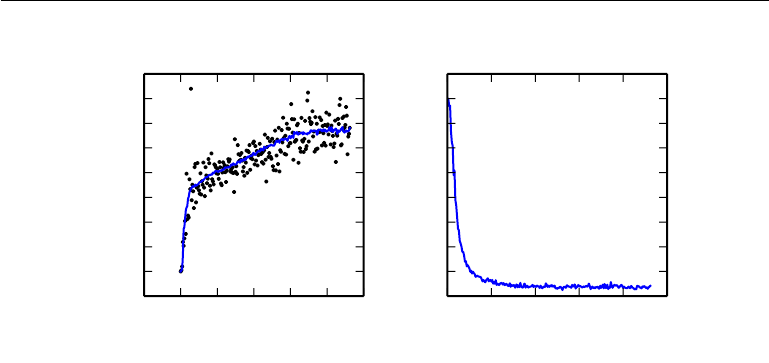

CHAPTER 8. OPTIMIZATION FOR TRAINING DEEP MODELS

−50 0 50 100 150 200 250

Training time (epochs)

−2

0

2

4

6

8

10

12

14

16

Gradient norm

0 50 100 150 200 250

Training time (epochs)

0.1

0.2

0.3

0.4

0.5

0.6

0.7

0.8

0.9

1.0

Classiﬁcation error rate

Figure 8.1: Gradient descent often does not arrive at a critical point of any kind. In this

example, the gradient norm increases throughout training of a convolutional network used

for object detection. (Left)A scatterplot showing how the norms of individual gradient

evaluations are distributed over time. To improve legibility, only one gradient norm

is plotted per epoch. The running average of all gradient norms is plotted as a solid

curve. The gradient norm clearly increases over time, rather than decreasing as we would

expect if the training process converged to a critical point. (Right)Despite the increasing

gradient, the training process is reasonably successful. The validation set classiﬁcation

error decreases to a low level.

network training task, one can monitor the squared gradient norm

g

g

and

the

g

Hg

term. In many cases, the gradient norm does not shrink signiﬁcantly

throughout learning, but the

g

Hg

term grows by more than an order of magnitude.

The result is that learning becomes very slow despite the presence of a strong

gradient because the learning rate must be shrunk to compensate for even stronger

curvature. Figure 8.1 shows an example of the gradient increasing signiﬁcantly

during the successful training of a neural network.

Though ill-conditioning is present in other settings besides neural network

training, some of the techniques used to combat it in other contexts are less

applicable to neural networks. For example, Newton’s method is an excellent tool

for minimizing convex functions with poorly conditioned Hessian matrices, but as

we argue in subsequent sections, Newton’s method requires signiﬁcant modiﬁcation

before it can be applied to neural networks.

280

CHAPTER 8. OPTIMIZATION FOR TRAINING DEEP MODELS

8.2.2 Local Minima

One of the most prominent features of a convex optimization problem is that it

can be reduced to the problem of ﬁnding a local minimum. Any local minimum is

guaranteed to be a global minimum. Some convex functions have a ﬂat region at

the bottom rather than a single global minimum point, but any point within such

a ﬂat region is an acceptable solution. When optimizing a convex function, we

know that we have reached a good solution if we ﬁnd a critical point of any kind.

With nonconvex functions, such as neural nets, it is possible to have many

local minima. Indeed, nearly any deep model is essentially guaranteed to have

an extremely large number of local minima. As we will see, however, this is not

necessarily a major problem.

Neural networks and any models with multiple equivalently parametrized latent

variables all have multiple local minima because of the

model identiﬁability

problem. A model is said to be identiﬁable if a suﬃciently large training set can

rule out all but one setting of the model’s parameters. Models with latent variables

are often not identiﬁable because we can obtain equivalent models by exchanging

latent variables with each other. For example, we could take a neural network and

modify layer 1 by swapping the incoming weight vector for unit

i

with the incoming

weight vector for unit

j

, then do the same for the outgoing weight vectors. If we

have

m

layers with

n

units each, then there are

n

!

m

ways of arranging the hidden

units. This kind of nonidentiﬁability is known as weight space symmetry.

In addition to weight space symmetry, many kinds of neural networks have

additional causes of nonidentiﬁability. For example, in any rectiﬁed linear or

maxout network, we can scale all the incoming weights and biases of a unit by

α

if we also scale all its outgoing weights by

1

α

. This means that—if the cost

function does not include terms such as weight decay that depend directly on the

weights rather than the models’ outputs—every local minimum of a rectiﬁed linear

or maxout network lies on an (

m ×n

)-dimensional hyperbola of equivalent local

minima.

These model identiﬁability issues mean that a neural network cost function

can have an extremely large or even uncountably inﬁnite amount of local minima.

However, all these local minima arising from nonidentiﬁability are equivalent to

each other in cost function value. As a result, these local minima are not a

problematic form of nonconvexity.

Local minima can be problematic if they have high cost in comparison to the

global minimum. One can construct small neural networks, even without hidden

units, that have local minima with higher cost than the global minimum (Sontag

281

CHAPTER 8. OPTIMIZATION FOR TRAINING DEEP MODELS

and Sussman, 1989; Brady et al., 1989; Gori and Tesi, 1992). If local minima

with high cost are common, this could pose a serious problem for gradient-based

optimization algorithms.

Whether networks of practical interest have many local minima of high cost

and whether optimization algorithms encounter them remain open questions. For

many years, most practitioners believed that local minima were a common problem

plaguing neural network optimization. Today, that does not appear to be the case.

The problem remains an active area of research, but experts now suspect that,

for suﬃciently large neural networks, most local minima have a low cost function

value, and that it is not important to ﬁnd a true global minimum rather than to

ﬁnd a point in parameter space that has low but not minimal cost (Saxe et al.,

2013; Dauphin et al., 2014; Goodfellow et al., 2015; Choromanska et al., 2014).

Many practitioners attribute nearly all diﬃculty with neural network optimiza-

tion to local minima. We encourage practitioners to carefully test for speciﬁc

problems. A test that can rule out local minima as the problem is plotting the

norm of the gradient over time. If the norm of the gradient does not shrink to

insigniﬁcant size, the problem is neither local minima nor any other kind of critical

point. In high-dimensional spaces, positively establishing that local minima are

the problem can be very diﬃcult. Many structures other than local minima also

have small gradients.

8.2.3 Plateaus, Saddle Points and Other Flat Regions

For many high-dimensional nonconvex functions, local minima (and maxima)

are in fact rare compared to another kind of point with zero gradient: a saddle

point. Some points around a saddle point have greater cost than the saddle point,

while others have a lower cost. At a saddle point, the Hessian matrix has both

positive and negative eigenvalues. Points lying along eigenvectors associated with

positive eigenvalues have greater cost than the saddle point, while points lying

along negative eigenvalues have lower value. We can think of a saddle point as

being a local minimum along one cross-section of the cost function and a local

maximum along another cross-section. See ﬁgure 4.5 for an illustration.

Many classes of random functions exhibit the following behavior: in low-

dimensional spaces, local minima are common. In higher-dimensional spaces, local

minima are rare, and saddle points are more common. For a function

f

:

R

n

→ R

of

this type, the expected ratio of the number of saddle points to local minima grows

exponentially with

n

. To understand the intuition behind this behavior, observe

that the Hessian matrix at a local minimum has only positive eigenvalues. The

282

CHAPTER 8. OPTIMIZATION FOR TRAINING DEEP MODELS

Hessian matrix at a saddle point has a mixture of positive and negative eigenvalues.

Imagine that the sign of each eigenvalue is generated by ﬂipping a coin. In a single

dimension, it is easy to obtain a local minimum by tossing a coin and getting heads

once. In

n

-dimensional space, it is exponentially unlikely that all

n

coin tosses will

be heads. See Dauphin et al. (2014) for a review of the relevant theoretical work.

An amazing property of many random functions is that the eigenvalues of the

Hessian become more likely to be positive as we reach regions of lower cost. In

our coin tossing analogy, this means we are more likely to have our coin come up

heads

n

times if we are at a critical point with low cost. It also means that local

minima are much more likely to have low cost than high cost. Critical points with

high cost are far more likely to be saddle points. Critical points with extremely

high cost are more likely to be local maxima.

This happens for many classes of random functions. Does it happen for neural

networks? Baldi and Hornik (1989) showed theoretically that shallow autoencoders

(feedforward networks trained to copy their input to their output, described in

chapter 14) with no nonlinearities have global minima and saddle points but no

local minima with higher cost than the global minimum. They observed without

proof that these results extend to deeper networks without nonlinearities. The

output of such networks is a linear function of their input, but they are useful

to study as a model of nonlinear neural networks because their loss function is

a nonconvex function of their parameters. Such networks are essentially just

multiple matrices composed together. Saxe et al. (2013) provided exact solutions

to the complete learning dynamics in such networks and showed that learning in

these models captures many of the qualitative features observed in the training of

deep models with nonlinear activation functions. Dauphin et al. (2014) showed

experimentally that real neural networks also have loss functions that contain very

many high-cost saddle points. Choromanska et al. (2014) provided additional

theoretical arguments, showing that another class of high-dimensional random

functions related to neural networks does so as well.

What are the implications of the proliferation of saddle points for training

algorithms? For ﬁrst-order optimization, algorithms that use only gradient infor-

mation, the situation is unclear. The gradient can often become very small near a

saddle point. On the other hand, gradient descent empirically seems able to escape

saddle points in many cases. Goodfellow et al. (2015) provided visualizations of

several learning trajectories of state-of-the-art neural networks, with an example

given in ﬁgure 8.2. These visualizations show a ﬂattening of the cost function near

a prominent saddle point, where the weights are all zero, but they also show the

gradient descent trajectory rapidly escaping this region. Goodfellow et al. (2015)

283

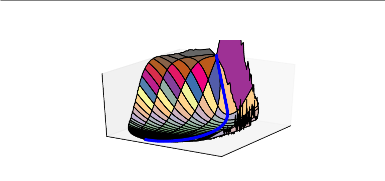

CHAPTER 8. OPTIMIZATION FOR TRAINING DEEP MODELS

Projection 2 of θ

Projection 1 of θ

J(θ)

Figure 8.2: A visualization of the cost function of a neural network. These visualizations

appear similar for feedforward neural networks, convolutional networks, and recurrent

networks applied to real object recognition and natural language processing tasks. Sur-

prisingly, these visualizations usually do not show many conspicuous obstacles. Prior

to the success of stochastic gradient descent for training very large models beginning in

roughly 2012, neural net cost function surfaces were generally believed to have much more

nonconvex structure than is revealed by these projections. The primary obstacle revealed

by this projection is a saddle point of high cost near where the parameters are initialized,

but, as indicated by the blue path, the SGD training trajectory escapes this saddle point

readily. Most of training time is spent traversing the relatively ﬂat valley of the cost

function, perhaps because of high noise in the gradient, poor conditioning of the Hessian

matrix in this region, or simply the need to circumnavigate the tall “mountain” visible in

the ﬁgure via an indirect arcing path. Image adapted with permission from Goodfellow

et al. (2015).

also argue that continuous-time gradient descent may be shown analytically to be

repelled from, rather than attracted to, a nearby saddle point, but the situation

may be diﬀerent for more realistic uses of gradient descent.

For Newton’s method, saddle points clearly constitute a problem. Gradient

descent is designed to move “downhill” and is not explicitly designed to seek a

critical point. Newton’s method, however, is designed to solve for a point where the

gradient is zero. Without appropriate modiﬁcation, it can jump to a saddle point.

The proliferation of saddle points in high-dimensional spaces presumably explains

why second-order methods have not succeeded in replacing gradient descent for

neural network training. Dauphin et al. (2014) introduced a

saddle-free Newton

method

for second-order optimization and showed that it improves signiﬁcantly

over the traditional version. Second-order methods remain diﬃcult to scale to large

neural networks, but this saddle-free approach holds promise if it can be scaled.

284

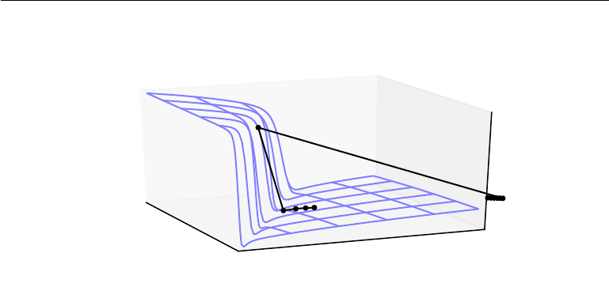

CHAPTER 8. OPTIMIZATION FOR TRAINING DEEP MODELS

Figure 8.3: The objective function for highly nonlinear deep neural networks or for

recurrent neural networks often contains sharp nonlinearities in parameter space resulting

from the multiplication of several parameters. These nonlinearities give rise to very

high derivatives in some places. When the parameters get close to such a cliﬀ region, a

gradient descent update can catapult the parameters very far, possibly losing most of the

optimization work that has been done. Figure adapted with permission from Pascanu

et al. (2013).

There are other kinds of points with zero gradient besides minima and saddle

points. Maxima are much like saddle points from the perspective of optimization—

many algorithms are not attracted to them, but unmodiﬁed Newton’s method

is. Maxima of many classes of random functions become exponentially rare in

high-dimensional space, just as minima do.

There may also be wide, ﬂat regions of constant value. In these locations,

the gradient and the Hessian are all zero. Such degenerate locations pose major

problems for all numerical optimization algorithms. In a convex problem, a wide,

ﬂat region must consist entirely of global minima, but in a general optimization

problem, such a region could correspond to a high value of the objective function.

8.2.4 Cliﬀs and Exploding Gradients

Neural networks with many layers often have extremely steep regions resembling

cliﬀs, as illustrated in ﬁgure 8.3. These result from the multiplication of several

large weights together. On the face of an extremely steep cliﬀ structure, the

gradient update step can move the parameters extremely far, usually jumping oﬀ

the cliﬀ structure altogether.

The cliﬀ can be dangerous whether we approach it from above or from below,

285

CHAPTER 8. OPTIMIZATION FOR TRAINING DEEP MODELS

but fortunately its most serious consequences can be avoided using the

gradient

clipping

heuristic described in section 10.11.1. The basic idea is to recall that the

gradient speciﬁes not the optimal step size, but only the optimal direction within

an inﬁnitesimal region. When the traditional gradient descent algorithm proposes

making a very large step, the gradient clipping heuristic intervenes to reduce the

step size, making it less likely to go outside the region where the gradient indicates

the direction of approximately steepest descent. Cliﬀ structures are most common

in the cost functions for recurrent neural networks, because such models involve a

multiplication of many factors, with one factor for each time step. Long temporal

sequences thus incur an extreme amount of multiplication.

8.2.5 Long-Term Dependencies

Another diﬃculty that neural network optimization algorithms must overcome

arises when the computational graph becomes extremely deep. Feedforward

networks with many layers have such deep computational graphs. So do recurrent

networks, described in chapter 10, which construct very deep computational graphs

by repeatedly applying the same operation at each time step of a long temporal

sequence. Repeated application of the same parameters gives rise to especially

pronounced diﬃculties.

For example, suppose that a computational graph contains a path that consists

of repeatedly multiplying by a matrix

W

. After

t

steps, this is equivalent to mul-

tiplying by

W

t

. Suppose that

W

has an eigendecomposition

W

=

V diag

(

λ

)

V

−1

.

In this simple case, it is straightforward to see that

W

t

=

V diag(λ)V

−1

t

= V diag(λ)

t

V

−1

. (8.11)

Any eigenvalues

λ

i

that are not near an absolute value of 1 will either explode if they

are greater than 1 in magnitude or vanish if they are less than 1 in magnitude. The

vanishing and exploding gradient problem

refers to the fact that gradients

through such a graph are also scaled according to

diag

(

λ

)

t

. Vanishing gradients

make it diﬃcult to know which direction the parameters should move to improve

the cost function, while exploding gradients can make learning unstable. The cliﬀ

structures described earlier that motivate gradient clipping are an example of the

exploding gradient phenomenon.

The repeated multiplication by

W

at each time step described here is very

similar to the

power method

algorithm used to ﬁnd the largest eigenvalue of

a matrix

W

and the corresponding eigenvector. From this point of view it is

not surprising that

x

W

t

will eventually discard all components of

x

that are

orthogonal to the principal eigenvector of W .

286

CHAPTER 8. OPTIMIZATION FOR TRAINING DEEP MODELS

Recurrent networks use the same matrix

W

at each time step, but feedforward

networks do not, so even very deep feedforward networks can largely avoid the

vanishing and exploding gradient problem (Sussillo, 2014).

We defer further discussion of the challenges of training recurrent networks

until section 10.7, after recurrent networks have been described in more detail.

8.2.6 Inexact Gradients

Most optimization algorithms are designed with the assumption that we have

access to the exact gradient or Hessian matrix. In practice, we usually have only

a noisy or even biased estimate of these quantities. Nearly every deep learning

algorithm relies on sampling-based estimates, at least insofar as using a minibatch

of training examples to compute the gradient.

In other cases, the objective function we want to minimize is actually intractable.

When the objective function is intractable, typically its gradient is intractable as

well. In such cases we can only approximate the gradient. These issues mostly

arise with the more advanced models we cover in part III. For example, contrastive

divergence gives a technique for approximating the gradient of the intractable

log-likelihood of a Boltzmann machine.

Various neural network optimization algorithms are designed to account for

imperfections in the gradient estimate. One can also avoid the problem by choosing

a surrogate loss function that is easier to approximate than the true loss.

8.2.7 Poor Correspondence between Local and Global Structure

Many of the problems we have discussed so far correspond to properties of the

loss function at a single point—it can be diﬃcult to make a single step if

J

(

θ

) is

poorly conditioned at the current point

θ

, or if

θ

lies on a cliﬀ, or if

θ

is a saddle

point hiding the opportunity to make progress downhill from the gradient.

It is possible to overcome all these problems at a single point and still perform

poorly if the direction that results in the most improvement locally does not point

toward distant regions of much lower cost.

Goodfellow et al. (2015) argue that much of the runtime of training is due to

the length of the trajectory needed to arrive at the solution. Figure 8.2 shows that

the learning trajectory spends most of its time tracing out a wide arc around a

mountain-shaped structure.

Much of research into the diﬃculties of optimization has focused on whether

287

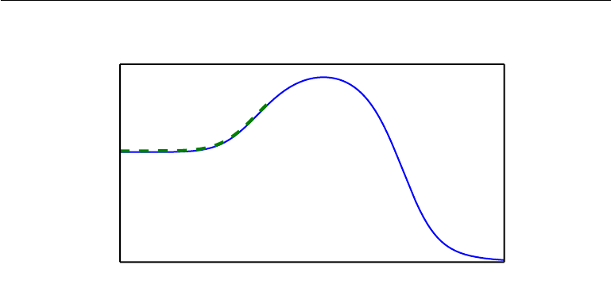

CHAPTER 8. OPTIMIZATION FOR TRAINING DEEP MODELS

θ

J(θ)

Figure 8.4: Optimization based on local downhill moves can fail if the local surface does

not point toward the global solution. Here we provide an example of how this can occur,

even if there are no saddle points or local minima. This example cost function contains

only asymptotes toward low values, not minima. The main cause of diﬃculty in this case

is being initialized on the wrong side of the “mountain” and not being able to traverse it.

In higher-dimensional space, learning algorithms can often circumnavigate such mountains,

but the trajectory associated with doing so may be long and result in excessive training

time, as illustrated in ﬁgure 8.2.

training arrives at a global minimum, a local minimum, or a saddle point, but in

practice, neural networks do not arrive at a critical point of any kind. Figure 8.1

shows that neural networks often do not arrive at a region of small gradient. Indeed,

such critical points do not even necessarily exist. For example, the loss function

−log p

(

y | x

;

θ

) can lack a global minimum point and instead asymptotically

approach some value as the model becomes more conﬁdent. For a classiﬁer with

discrete

y

and

p

(

y | x

) provided by a softmax, the negative log-likelihood can

become arbitrarily close to zero if the model is able to correctly classify every

example in the training set, but it is impossible to actually reach the value of

zero. Likewise, a model of real values

p

(

y | x

) =

N

(

y

;

f

(

θ

)

, β

−1

) can have negative

log-likelihood that asymptotes to negative inﬁnity—if

f

(

θ

) is able to correctly

predict the value of all training set

y

targets, the learning algorithm will increase

β

without bound. See ﬁgure 8.4 for an example of a failure of local optimization

to ﬁnd a good cost function value even in the absence of any local minima or

saddle points.

Future research will need to develop further understanding of the factors that

inﬂuence the length of the learning trajectory and better characterize the outcome

of the process.

288

CHAPTER 8. OPTIMIZATION FOR TRAINING DEEP MODELS

Many existing research directions are aimed at ﬁnding good initial points for

problems that have diﬃcult global structure, rather than at developing algorithms

that use nonlocal moves.

Gradient descent and essentially all learning algorithms that are eﬀective for

training neural networks are based on making small local moves. The previous

sections have primarily focused on how the correct direction of these local moves

can be diﬃcult to compute. We may be able to compute some properties of the

objective function, such as its gradient, only approximately, with bias or variance

in our estimate of the correct direction. In these cases, local descent may or may

not deﬁne a reasonably short path to a valid solution, but we are not actually

able to follow the local descent path. The objective function may have issues,

such as poor conditioning or discontinuous gradients, causing the region where

the gradient provides a good model of the objective function to be very small. In

these cases, local descent with steps of size

may deﬁne a reasonably short path

to the solution, but we are only able to compute the local descent direction with

steps of size

δ

. In these cases, local descent may deﬁne a path to the solution,

but the path contains many steps, so following it incurs a high computational cost.

Sometimes local information provides us no guide, such as when the function has

a wide ﬂat region, or if we manage to land exactly on a critical point (usually this

latter scenario only happens to methods that solve explicitly for critical points,

such as Newton’s method). In these cases, local descent does not deﬁne a path to

a solution at all. In other cases, local moves can be too greedy and lead us along a

path that moves downhill but away from any solution, as in ﬁgure 8.4, or along an

unnecessarily long trajectory to the solution, as in ﬁgure 8.2. Currently, we do not

understand which of these problems are most relevant to making neural network

optimization diﬃcult, and this is an active area of research.

Regardless of which of these problems are most signiﬁcant, all of them might be

avoided if there exists a region of space connected reasonably directly to a solution

by a path that local descent can follow, and if we are able to initialize learning

within that well-behaved region. This last view suggests research into choosing

good initial points for traditional optimization algorithms to use.

8.2.8 Theoretical Limits of Optimization

Several theoretical results show that there are limits on the performance of any

optimization algorithm we might design for neural networks (Blum and Rivest,

1992; Judd, 1989; Wolpert and MacReady, 1997). Typically these results have

little bearing on the use of neural networks in practice.

289

CHAPTER 8. OPTIMIZATION FOR TRAINING DEEP MODELS

Some theoretical results apply only when the units of a neural network output

discrete values. Most neural network units output smoothly increasing values

that make optimization via local search feasible. Some theoretical results show

that there exist problem classes that are intractable, but it can be diﬃcult to tell

whether a particular problem falls into that class. Other results show that ﬁnding

a solution for a network of a given size is intractable, but in practice we can ﬁnd a

solution easily by using a larger network for which many more parameter settings

correspond to an acceptable solution. Moreover, in the context of neural network

training, we usually do not care about ﬁnding the exact minimum of a function,

but seek only to reduce its value suﬃciently to obtain good generalization error.

Theoretical analysis of whether an optimization algorithm can accomplish this

goal is extremely diﬃcult. Developing more realistic bounds on the performance of

optimization algorithms therefore remains an important goal for machine learning

research.

8.3 Basic Algorithms

We have previously introduced the gradient descent (section 4.3) algorithm that

follows the gradient of an entire training set downhill. This may be accelerated

considerably by using stochastic gradient descent to follow the gradient of randomly

selected minibatches downhill, as discussed in section 5.9 and section 8.1.3.

8.3.1 Stochastic Gradient Descent

Stochastic gradient descent (SGD) and its variants are probably the most used

optimization algorithms for machine learning in general and for deep learning

in particular. As discussed in section 8.1.3, it is possible to obtain an unbiased

estimate of the gradient by taking the average gradient on a minibatch of

m

examples drawn i.i.d from the data-generating distribution.

Algorithm 8.1 shows how to follow this estimate of the gradient downhill.

A crucial parameter for the SGD algorithm is the learning rate. Previously, we

have described SGD as using a ﬁxed learning rate

. In practice, it is necessary to

gradually decrease the learning rate over time, so we now denote the learning rate

at iteration k as

k

.

This is because the SGD gradient estimator introduces a source of noise (the

random sampling of

m

training examples) that does not vanish even when we arrive

at a minimum. By comparison, the true gradient of the total cost function becomes

small and then

0

when we approach and reach a minimum using batch gradient

290

[figure not shown]

CHAPTER 8. OPTIMIZATION FOR TRAINING DEEP MODELS

Algorithm 8.1 Stochastic gradient descent (SGD) update

Require: Learning rate schedule

1

,

2

, . . .

Require: Initial parameter θ

k ← 1

while stopping criterion not met do

Sample a minibatch of

m

examples from the training set

{x

(1)

, . . . , x

(m)

}

with

corresponding targets y

(i)

.

Compute gradient estimate:

ˆ

g ←

1

m

∇

θ

i

L(f(x

(i)

; θ), y

(i)

)

Apply update: θ ← θ −

k

ˆ

g

k ← k + 1

end while

descent, so batch gradient descent can use a ﬁxed learning rate. A suﬃcient

condition to guarantee convergence of SGD is that

∞

k=1

k

= ∞, and (8.12)

∞

k=1

2

k

< ∞. (8.13)

In practice, it is common to decay the learning rate linearly until iteration τ:

k

= (1 − α)

0

+ α

τ

(8.14)

with α =

k

τ

. After iteration τ , it is common to leave  constant.

The learning rate may be chosen by trial and error, but it is usually best

to choose it by monitoring learning curves that plot the objective function as a

function of time. This is more of an art than a science, and most guidance on this

subject should be regarded with some skepticism. When using the linear schedule,

the parameters to choose are

0

,

τ

, and

τ

. Usually

τ

may be set to the number of

iterations required to make a few hundred passes through the training set. Usually

τ

should be set to roughly 1 percent the value of

0

. The main question is how to

set

0

. If it is too large, the learning curve will show violent oscillations, with the

cost function often increasing signiﬁcantly. Gentle oscillations are ﬁne, especially if

training with a stochastic cost function, such as the cost function arising from the

use of dropout. If the learning rate is too low, learning proceeds slowly, and if the

initial learning rate is too low, learning may become stuck with a high cost value.

Typically, the optimal initial learning rate, in terms of total training time and the

291

CHAPTER 8. OPTIMIZATION FOR TRAINING DEEP MODELS

ﬁnal cost value, is higher than the learning rate that yields the best performance

after the ﬁrst 100 iterations or so. Therefore, it is usually best to monitor the ﬁrst

several iterations and use a learning rate that is higher than the best-performing

learning rate at this time, but not so high that it causes severe instability.

The most important property of SGD and related minibatch or online gradient-

based optimization is that computation time per update does not grow with the

number of training examples. This allows convergence even when the number

of training examples becomes very large. For a large enough dataset, SGD may

converge to within some ﬁxed tolerance of its ﬁnal test set error before it has

processed the entire training set.

To study the convergence rate of an optimization algorithm it is common to

measure the

excess error J

(

θ

)

− min

θ

J

(

θ

), which is the amount by which the

current cost function exceeds the minimum possible cost. When SGD is applied to

a convex problem, the excess error is

O

(

1

√

k

) after

k

iterations, while in the strongly

convex case, it is

O

(

1

k

). These bounds cannot be improved unless extra conditions

are assumed. Batch gradient descent enjoys better convergence rates than stochastic

gradient descent in theory. However, the Cramér-Rao bound (Cramér, 1946; Rao,

1945) states that generalization error cannot decrease faster than

O

(

1

k

). Bottou

and Bousquet (2008) argue that it therefore may not be worthwhile to pursue

an optimization algorithm that converges faster than

O

(

1

k

) for machine learning

tasks—faster convergence presumably corresponds to overﬁtting. Moreover, the

asymptotic analysis obscures many advantages that stochastic gradient descent

has after a small number of steps. With large datasets, the ability of SGD to

make rapid initial progress while evaluating the gradient for very few examples

outweighs its slow asymptotic convergence. Most of the algorithms described in

the remainder of this chapter achieve beneﬁts that matter in practice but are lost

in the constant factors obscured by the

O

(

1

k

) asymptotic analysis. One can also

trade oﬀ the beneﬁts of both batch and stochastic gradient descent by gradually

increasing the minibatch size during the course of learning.

For more information on SGD, see Bottou (1998).

8.3.2 Momentum

While stochastic gradient descent remains a popular optimization strategy, learning

with it can sometimes be slow. The method of momentum (Polyak, 1964) is

designed to accelerate learning, especially in the face of high curvature, small but

consistent gradients, or noisy gradients. The momentum algorithm accumulates

an exponentially decaying moving average of past gradients and continues to move

292

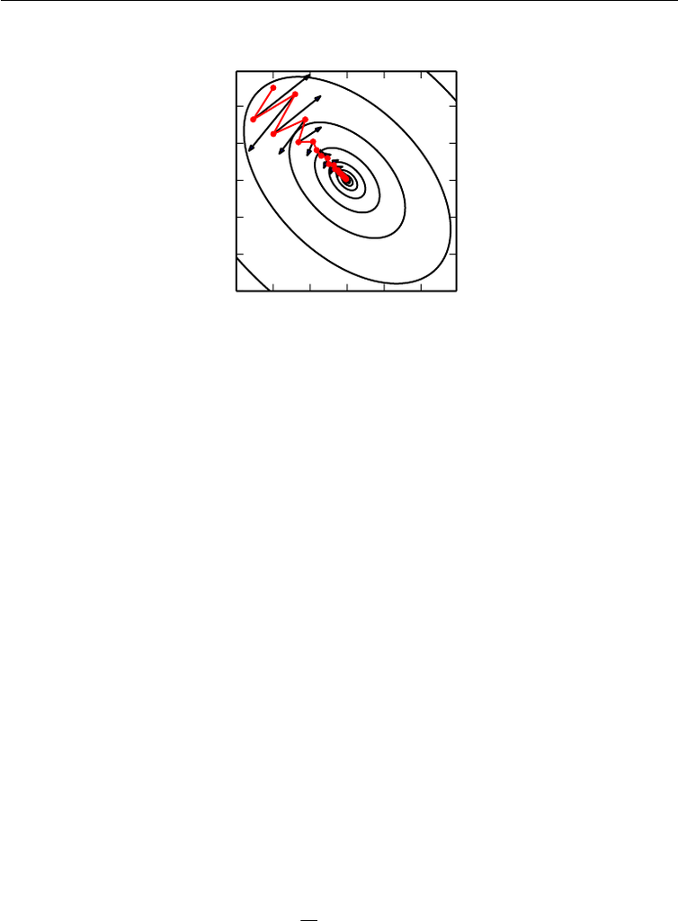

CHAPTER 8. OPTIMIZATION FOR TRAINING DEEP MODELS

−30 −20 −10 0 10 20

−30

−20

−10

0

10

20

Figure 8.5: Momentum aims primarily to solve two problems: poor conditioning of the

Hessian matrix and variance in the stochastic gradient. Here, we illustrate how momentum

overcomes the ﬁrst of these two problems. The contour lines depict a quadratic loss

function with a poorly conditioned Hessian matrix. The red path cutting across the

contours indicates the path followed by the momentum learning rule as it minimizes this

function. At each step along the way, we draw an arrow indicating the step that gradient

descent would take at that point. We can see that a poorly conditioned quadratic objective

looks like a long, narrow valley or canyon with steep sides. Momentum correctly traverses

the canyon lengthwise, while gradient steps waste time moving back and forth across the

narrow axis of the canyon. Compare also ﬁgure 4.6, which shows the behavior of gradient

descent without momentum.

in their direction. The eﬀect of momentum is illustrated in ﬁgure 8.5.

Formally, the momentum algorithm introduces a variable

v

that plays the role

of velocity—it is the direction and speed at which the parameters move through

parameter space. The velocity is set to an exponentially decaying average of the

negative gradient. The name

momentum

derives from a physical analogy, in

which the negative gradient is a force moving a particle through parameter space,

according to Newton’s laws of motion. Momentum in physics is mass times velocity.

In the momentum learning algorithm, we assume unit mass, so the velocity vector

v

may also be regarded as the momentum of the particle. A hyperparameter

α ∈

[0

,

1)

determines how quickly the contributions of previous gradients exponentially decay.

The update rule is given by

v ← αv − ∇

θ

1

m

m

i=1

L(f(x

(i)

; θ), y

(i)

)

, (8.15)

θ ← θ + v. (8.16)

293

[figure not shown]

CHAPTER 8. OPTIMIZATION FOR TRAINING DEEP MODELS

Algorithm 8.2 Stochastic gradient descent (SGD) with momentum

Require: Learning rate , momentum parameter α

Require: Initial parameter θ, initial velocity v

while stopping criterion not met do

Sample a minibatch of

m

examples from the training set

{x

(1)

, . . . , x

(m)

}

with

corresponding targets y

(i)

.

Compute gradient estimate: g ←

1

m

∇

θ

i

L(f(x

(i)

; θ), y

(i)

).

Compute velocity update: v ← αv − g.

Apply update: θ ← θ + v.

end while

The velocity

v

accumulates the gradient elements

∇

θ

1

m

m

i=1

L(f(x

(i)

; θ), y

(i)

)

.

The larger

α

is relative to

, the more previous gradients aﬀect the current direction.

The SGD algorithm with momentum is given in algorithm 8.2.

Previously, the size of the step was simply the norm of the gradient multiplied

by the learning rate. Now, the size of the step depends on how large and how

aligned a sequence of gradients are. The step size is largest when many successive

gradients point in exactly the same direction. If the momentum algorithm always

observes gradient

g

, then it will accelerate in the direction of

−g

, until reaching a

terminal velocity where the size of each step is

||g||

1 − α

. (8.17)

It is thus helpful to think of the momentum hyperparameter in terms of

1

1−α

. For

example,

α

= 0

.

9 corresponds to multiplying the maximum speed by 10 relative to

the gradient descent algorithm.

Common values of

α

used in practice include 0

.

5, 0

.

9, and 0

.

99. Like the

learning rate,

α

may also be adapted over time. Typically it begins with a small

value and is later raised. Adapting

α

over time is less important than shrinking

over time.

We can view the momentum algorithm as simulating a particle subject to

continuous-time Newtonian dynamics. The physical analogy can help build intuition

for how the momentum and gradient descent algorithms behave.

The position of the particle at any point in time is given by

θ

(

t

). The particle

experiences net force f(t). This force causes the particle to accelerate:

f(t) =

∂

2

∂t

2

θ(t). (8.18)

294

[figure not shown]

CHAPTER 8. OPTIMIZATION FOR TRAINING DEEP MODELS

Rather than viewing this as a second-order diﬀerential equation of the position,

we can introduce the variable

v

(

t

) representing the velocity of the particle at time

t and rewrite the Newtonian dynamics as a ﬁrst-order diﬀerential equation:

v(t) =

∂

∂t

θ(t), (8.19)

f(t) =

∂

∂t

v(t). (8.20)

The momentum algorithm then consists of solving the diﬀerential equations via

numerical simulation. A simple numerical method for solving diﬀerential equations

is Euler’s method, which simply consists of simulating the dynamics deﬁned by

the equation by taking small, ﬁnite steps in the direction of each gradient.

This explains the basic form of the momentum update, but what speciﬁcally are

the forces? One force is proportional to the negative gradient of the cost function:

−∇

θ

J

(

θ

). This force pushes the particle downhill along the cost function surface.

The gradient descent algorithm would simply take a single step based on each

gradient, but the Newtonian scenario used by the momentum algorithm instead

uses this force to alter the velocity of the particle. We can think of the particle

as being like a hockey puck sliding down an icy surface. Whenever it descends a

steep part of the surface, it gathers speed and continues sliding in that direction

until it begins to go uphill again.

One other force is necessary. If the only force is the gradient of the cost function,

then the particle might never come to rest. Imagine a hockey puck sliding down

one side of a valley and straight up the other side, oscillating back and forth forever,

assuming the ice is perfectly frictionless. To resolve this problem, we add one

other force, proportional to

−v

(

t

). In physics terminology, this force corresponds

to viscous drag, as if the particle must push through a resistant medium such as

syrup. This causes the particle to gradually lose energy over time and eventually

converge to a local minimum.

Why do we use

−v

(

t

) and viscous drag in particular? Part of the reason to

use

−v

(

t

) is mathematical convenience—an integer power of the velocity is easy

to work with. Yet other physical systems have other kinds of drag based on other

integer powers of the velocity. For example, a particle traveling through the air

experiences turbulent drag, with force proportional to the square of the velocity,

while a particle moving along the ground experiences dry friction, with a force

of constant magnitude. We can reject each of these options. Turbulent drag,

proportional to the square of the velocity, becomes very weak when the velocity is

small. It is not powerful enough to force the particle to come to rest. A particle

with a nonzero initial velocity that experiences only the force of turbulent drag

295

[figure not shown]

CHAPTER 8. OPTIMIZATION FOR TRAINING DEEP MODELS

will move away from its initial position forever, with the distance from the starting

point growing like

O

(

log t

). We must therefore use a lower power of the velocity.

If we use a power of zero, representing dry friction, then the force is too strong.

When the force due to the gradient of the cost function is small but nonzero, the

constant force due to friction can cause the particle to come to rest before reaching

a local minimum. Viscous drag avoids both of these problems—it is weak enough

that the gradient can continue to cause motion until a minimum is reached, but

strong enough to prevent motion if the gradient does not justify moving.

8.3.3 Nesterov Momentum

Sutskever et al. (2013) introduced a variant of the momentum algorithm that was

inspired by Nesterov’s accelerated gradient method (Nesterov, 1983, 2004). The

update rules in this case are given by

v ← αv − ∇

θ

1

m

m

i=1

L

f(x

(i)

; θ + αv), y

(i)

, (8.21)

θ ← θ + v, (8.22)

where the parameters

α

and

play a similar role as in the standard momentum

method. The diﬀerence between Nesterov momentum and standard momentum

is where the gradient is evaluated. With Nesterov momentum, the gradient is

evaluated after the current velocity is applied. Thus one can interpret Nesterov

momentum as attempting to add a correction factor to the standard method

of momentum. The complete Nesterov momentum algorithm is presented in

algorithm 8.3.

In the convex batch gradient case, Nesterov momentum brings the rate of

convergence of the excess error from

O

(1

/k

) (after

k

steps) to

O

(1

/k

2

) as shown

by Nesterov (1983). Unfortunately, in the stochastic gradient case, Nesterov

momentum does not improve the rate of convergence.

8.4 Parameter Initialization Strategies

Some optimization algorithms are not iterative by nature and simply solve for a

solution point. Other optimization algorithms are iterative by nature but, when

applied to the right class of optimization problems, converge to acceptable solutions

in an acceptable amount of time regardless of initialization. Deep learning training

algorithms usually do not have either of these luxuries. Training algorithms for

296

[figure not shown]

CHAPTER 8. OPTIMIZATION FOR TRAINING DEEP MODELS

Algorithm 8.3 Stochastic gradient descent (SGD) with Nesterov momentum

Require: Learning rate , momentum parameter α

Require: Initial parameter θ, initial velocity v

while stopping criterion not met do

Sample a minibatch of

m

examples from the training set

{x

(1)

, . . . , x

(m)

}

with

corresponding labels y

(i)

.

Apply interim update:

˜

θ ← θ + αv.

Compute gradient (at interim point): g ←

1

m

∇

˜

θ

i

L(f(x

(i)

;

˜

θ), y

(i)

).

Compute velocity update: v ← αv − g.

Apply update: θ ← θ + v.

end while

deep learning models are usually iterative and thus require the user to specify some

initial point from which to begin the iterations. Moreover, training deep models is

a suﬃciently diﬃcult task that most algorithms are strongly aﬀected by the choice

of initialization. The initial point can determine whether the algorithm converges

at all, with some initial points being so unstable that the algorithm encounters

numerical diﬃculties and fails altogether. When learning does converge, the initial

point can determine how quickly learning converges and whether it converges to

a point with high or low cost. Also, points of comparable cost can have wildly

varying generalization error, and the initial point can aﬀect the generalization

as well.

Modern initialization strategies are simple and heuristic. Designing improved

initialization strategies is a diﬃcult task because neural network optimization is

not yet well understood. Most initialization strategies are based on achieving some

nice properties when the network is initialized. However, we do not have a good

understanding of which of these properties are preserved under which circumstances

after learning begins to proceed. A further diﬃculty is that some initial points

may be beneﬁcial from the viewpoint of optimization but detrimental from the

viewpoint of generalization. Our understanding of how the initial point aﬀects

generalization is especially primitive, oﬀering little to no guidance for how to select

the initial point.

Perhaps the only property known with complete certainty is that the initial

parameters need to “break symmetry” between diﬀerent units. If two hidden

units with the same activation function are connected to the same inputs, then

these units must have diﬀerent initial parameters. If they have the same initial

parameters, then a deterministic learning algorithm applied to a deterministic cost

and model will constantly update both of these units in the same way. Even if the

297

CHAPTER 8. OPTIMIZATION FOR TRAINING DEEP MODELS

model or training algorithm is capable of using stochasticity to compute diﬀerent

updates for diﬀerent units (for example, if one trains with dropout), it is usually

best to initialize each unit to compute a diﬀerent function from all the other units.

This may help to make sure that no input patterns are lost in the null space

of forward propagation and that no gradient patterns are lost in the null space

of back-propagation. The goal of having each unit compute a diﬀerent function

motivates random initialization of the parameters. We could explicitly search for

a large set of basis functions that are all mutually diﬀerent from each other, but

this often incurs a noticeable computational cost. For example, if we have at most

as many outputs as inputs, we could use Gram-Schmidt orthogonalization on an

initial weight matrix and be guaranteed that each unit would compute a very

diﬀerent function from each other unit. Random initialization from a high-entropy

distribution over a high-dimensional space is computationally cheaper and unlikely

to assign any units to compute the same function as each other.

Typically, we set the biases for each unit to heuristically chosen constants, and

initialize only the weights randomly. Extra parameters—for example, parameters

encoding the conditional variance of a prediction—are usually set to heuristically

chosen constants much like the biases are.

We almost always initialize all the weights in the model to values drawn

randomly from a Gaussian or uniform distribution. The choice of Gaussian or

uniform distribution does not seem to matter much but has not been exhaustively

studied. The scale of the initial distribution, however, does have a large eﬀect on

both the outcome of the optimization procedure and the ability of the network to

generalize.

Larger initial weights will yield a stronger symmetry-breaking eﬀect, helping

to avoid redundant units. They also help to avoid losing signal during forward or

back-propagation through the linear component of each layer—larger values in the

matrix result in larger outputs of matrix multiplication. Initial weights that are

too large may, however, result in exploding values during forward propagation or

back-propagation. In recurrent networks, large weights can also result in

chaos

(such extreme sensitivity to small perturbations of the input that the behavior

of the deterministic forward propagation procedure appears random). To some

extent, the exploding gradient problem can be mitigated by gradient clipping

(thresholding the values of the gradients before performing a gradient descent step).

Large weights may also result in extreme values that cause the activation function

to saturate, causing complete loss of gradient through saturated units. These

competing factors determine the ideal initial scale of the weights.

The perspectives of regularization and optimization can give very diﬀerent

298

[figure not shown]

CHAPTER 8. OPTIMIZATION FOR TRAINING DEEP MODELS

insights into how we should initialize a network. The optimization perspective

suggests that the weights should be large enough to propagate information suc-

cessfully, but some regularization concerns encourage making them smaller. The

use of an optimization algorithm, such as stochastic gradient descent, that makes

small incremental changes to the weights and tends to halt in areas that are nearer

to the initial parameters (whether due to getting stuck in a region of low gradient,

or due to triggering some early stopping criterion based on overﬁtting) expresses a

prior that the ﬁnal parameters should be close to the initial parameters. Recall

from section 7.8 that gradient descent with early stopping is equivalent to weight

decay for some models. In the general case, gradient descent with early stopping

is not the same as weight decay, but it does provide a loose analogy for thinking

about the eﬀect of initialization. We can think of initializing the parameters

θ

to

θ

0

as being similar to imposing a Gaussian prior

p

(

θ

) with mean

θ

0

. From this

point of view, it makes sense to choose

θ

0

to be near 0. This prior says that it is

more likely that units do not interact with each other than that they do interact.

Units interact only if the likelihood term of the objective function expresses a

strong preference for them to interact. On the other hand, if we initialize

θ

0

to

large values, then our prior speciﬁes which units should interact with each other,

and how they should interact.

Some heuristics are available for choosing the initial scale of the weights. One

heuristic is to initialize the weights of a fully connected layer with

m

inputs and

n

outputs by sampling each weight from

U

(

−

1

√

m

,

1

√

m

), while Glorot and Bengio

(2010) suggest using the normalized initialization

W

i,j

∼ U

−

6

m + n

,

6

m + n

. (8.23)

This latter heuristic is designed to compromise between the goal of initializing

all layers to have the same activation variance and the goal of initializing all

layers to have the same gradient variance. The formula is derived using the

assumption that the network consists only of a chain of matrix multiplications,

with no nonlinearities. Real neural networks obviously violate this assumption,

but many strategies designed for the linear model perform reasonably well on its

nonlinear counterparts.

Saxe et al. (2013) recommend initializing to random orthogonal matrices, with

a carefully chosen scaling or

gain

factor

g

that accounts for the nonlinearity applied

at each layer. They derive speciﬁc values of the scaling factor for diﬀerent types of

nonlinear activation functions. This initialization scheme is also motivated by a

model of a deep network as a sequence of matrix multiplies without nonlinearities.

Under such a model, this initialization scheme guarantees that the total number of

training iterations required to reach convergence is independent of depth.

Increasing the scaling factor

g

pushes the network toward the regime where

activations increase in norm as they propagate forward through the network and

gradients increase in norm as they propagate backward. Sussillo (2014) showed that

setting the gain factor correctly is suﬃcient to train networks as deep as 1,000 layers,

without needing to use orthogonal initializations. A key insight of this approach

is that in feedforward networks, activations and gradients can grow or shrink on

each step of forward or back-propagation, following a random walk behavior. This

is because feedforward networks use a diﬀerent weight matrix at each layer. If this

random walk is tuned to preserve norms, then feedforward networks can mostly

avoid the vanishing and exploding gradients problem that arises when the same

weight matrix is used at each step, as described in section 8.2.5.

Unfortunately, these optimal criteria for initial weights often do not lead to

optimal performance. This may be for three diﬀerent reasons. First, we may

be using the wrong criteria—it may not actually be beneﬁcial to preserve the

norm of a signal throughout the entire network. Second, the properties imposed

at initialization may not persist after learning has begun to proceed. Third, the

criteria might succeed at improving the speed of optimization but inadvertently

increase generalization error. In practice, we usually need to treat the scale of the

weights as a hyperparameter whose optimal value lies somewhere roughly near but

not exactly equal to the theoretical predictions.

One drawback to scaling rules that set all the initial weights to have the same

standard deviation, such as

1

√

m

, is that every individual weight becomes extremely

small when the layers become large. Martens (2010) introduced an alternative

initialization scheme called

sparse initialization

, in which each unit is initialized

to have exactly

k

nonzero weights. The idea is to keep the total amount of input to

the unit independent from the number of inputs

m

without making the magnitude

of individual weight elements shrink with

m

. Sparse initialization helps to achieve

more diversity among the units at initialization time. However, it also imposes

a very strong prior on the weights that are chosen to have large Gaussian values.

Because it takes a long time for gradient descent to shrink “incorrect” large values,

this initialization scheme can cause problems for units, such as maxout units, that

have several ﬁlters that must be carefully coordinated with each other.

When computational resources allow it, it is usually a good idea to treat the

initial scale of the weights for each layer as a hyperparameter, and to choose these

scales using a hyperparameter search algorithm described in section 11.4.2, such

as random search. The choice of whether to use dense or sparse initialization

can also be made a hyperparameter. Alternately, one can manually search for

the best initial scales. A good rule of thumb for choosing the initial scales is to

look at the range or standard deviation of activations or gradients on a single

minibatch of data. If the weights are too small, the range of activations across the

minibatch will shrink as the activations propagate forward through the network.

By repeatedly identifying the ﬁrst layer with unacceptably small activations and

increasing its weights, it is possible to eventually obtain a network with reasonable

initial activations throughout. If learning is still too slow at this point, it can be

useful to look at the range or standard deviation of the gradients as well as the

activations. This procedure can in principle be automated and is generally less

computationally costly than hyperparameter optimization based on validation set

error because it is based on feedback from the behavior of the initial model on a

single batch of data, rather than on feedback from a trained model on the validation

set. While long used heuristically, this protocol has recently been speciﬁed more

formally and studied by Mishkin and Matas (2015).

So far we have focused on the initialization of the weights. Fortunately,

initialization of other parameters is typically easier.

The approach for setting the biases must be coordinated with the approach

for setting the weights. Setting the biases to zero is compatible with most weight

initialization schemes. There are a few situations where we may set some biases to

nonzero values:

•

If a bias is for an output unit, then it is often beneﬁcial to initialize the bias to

obtain the right marginal statistics of the output. To do this, we assume that

the initial weights are small enough that the output of the unit is determined

only by the bias. This justiﬁes setting the bias to the inverse of the activation

function applied to the marginal statistics of the output in the training set.

For example, if the output is a distribution over classes, and this distribution

is a highly skewed distribution with the marginal probability of class

i

given

by element

c

i

of some vector

c

, then we can set the bias vector

b

by solving

the equation

softmax

(

b

) =

c

. This applies not only to classiﬁers but also to

models we will encounter in Part III, such as autoencoders and Boltzmann

machines. These models have layers whose output should resemble the input

data

x

, and it can be very helpful to initialize the biases of such layers to

match the marginal distribution over x.

•

Sometimes we may want to choose the bias to avoid causing too much

saturation at initialization. For example, we may set the bias of a ReLU

hidden unit to 0.1 rather than 0 to avoid saturating the ReLU at initialization.

This approach is not compatible with weight initialization schemes that do

not expect strong input from the biases though. For example, it is not

recommended for use with random walk initialization (Sussillo, 2014).

•

Sometimes a unit controls whether other units are able to participate in a

function. In such situations, we have a unit with output

u

and another unit

h ∈

[0

,

1], and they are multiplied together to produce an output

uh

. We

can view

h

as a gate that determines whether

uh ≈ u

or

uh ≈

0. In these

situations, we want to set the bias for

h

so that

h ≈

1 most of the time at

initialization. Otherwise

u

does not have a chance to learn. For example,

Jozefowicz et al. (2015) advocate setting the bias to 1 for the forget gate of

the LSTM model, described in section 10.10.

Another common type of parameter is a variance or precision parameter. For

example, we can perform linear regression with a conditional variance estimate

using the model

p(y | x) = N(y | w

T

x + b, 1/β), (8.24)

where

β

is a precision parameter. We can usually initialize variance or precision

parameters to 1 safely. Another approach is to assume the initial weights are close

enough to zero that the biases may be set while ignoring the eﬀect of the weights,

then set the biases to produce the correct marginal mean of the output, and set

the variance parameters to the marginal variance of the output in the training set.

Besides these simple constant or random methods of initializing model parame-

ters, it is possible to initialize model parameters using machine learning. A common

strategy discussed in part III of this book is to initialize a supervised model with

the parameters learned by an unsupervised model trained on the same inputs.

One can also perform supervised training on a related task. Even performing

supervised training on an unrelated task can sometimes yield an initialization that

oﬀers faster convergence than a random initialization. Some of these initialization

strategies may yield faster convergence and better generalization because they

encode information about the distribution in the initial parameters of the model.

Others apparently perform well primarily because they set the parameters to have

the right scale or set diﬀerent units to compute diﬀerent functions from each other.

8.5 Algorithms with Adaptive Learning Rates

Neural network researchers have long realized that the learning rate is reliably

one of the most diﬃcult to set hyperparameters because it signiﬁcantly aﬀects

model performance. As we discuss in sections 4.3 and 8.2, the cost is often highly

sensitive to some directions in parameter space and insensitive to others. The

momentum algorithm can mitigate these issues somewhat, but it does so at the

expense of introducing another hyperparameter. In the face of this, it is natural

to ask if there is another way. If we believe that the directions of sensitivity are

somewhat axis aligned, it can make sense to use a separate learning rate for each

parameter and automatically adapt these learning rates throughout the course of

learning.

The delta-bar-delta algorithm (Jacobs, 1988) is an early heuristic approach

to adapting individual learning rates for model parameters during training. The

approach is based on a simple idea: if the partial derivative of the loss, with respect

to a given model parameter, remains the same sign, then the learning rate should

increase. If that partial derivative changes sign, then the learning rate should

decrease. Of course, this kind of rule can only be applied to full batch optimization.

More recently, a number of incremental (or mini batch-based) methods have

been introduced that adapt the learning rates of model parameters. In this section,

we brieﬂy review a few of these algorithms.

8.5.1 AdaGrad

The

AdaGrad

algorithm, shown in algorithm 8.4, individually adapts the learning

rates of all model parameters by scaling them inversely proportional to the square

root of the sum of all the historical squared values of the gradient (Duchi et al.,

2011). The parameters with the largest partial derivative of the loss have a

correspondingly rapid decrease in their learning rate, while parameters with small

partial derivatives have a relatively small decrease in their learning rate. The net

eﬀect is greater progress in the more gently sloped directions of parameter space.

In the context of convex optimization, the AdaGrad algorithm enjoys some

desirable theoretical properties. Empirically, however, for training deep neural

network models, the accumulation of squared gradients from the beginning of

training can result in a premature and excessive decrease in the eﬀective learning

rate. AdaGrad performs well for some but not all deep learning models.

8.5.2 RMSProp

The

RMSProp

algorithm (Hinton, 2012) modiﬁes AdaGrad to perform better in

the nonconvex setting by changing the gradient accumulation into an exponentially

weighted moving average. AdaGrad is designed to converge rapidly when applied to

a convex function. When applied to a nonconvex function to train a neural network,

[figure not shown]

the learning trajectory may pass through many diﬀerent structures and eventually

arrive at a region that is a locally convex bowl. AdaGrad shrinks the learning rate

according to the entire history of the squared gradient and may have made the

learning rate too small before arriving at such a convex structure. RMSProp uses

an exponentially decaying average to discard history from the extreme past so that

it can converge rapidly after ﬁnding a convex bowl, as if it were an instance of the

AdaGrad algorithm initialized within that bowl.

Algorithm 8.4 The AdaGrad algorithm

Require: Global learning rate

Require: Initial parameter θ

Require: Small constant δ, perhaps 10

−7

, for numerical stability

Initialize gradient accumulation variable r = 0

while stopping criterion not met do

Sample a minibatch of

m

examples from the training set

{x

(1)

, . . . , x

(m)

}

with

corresponding targets y

(i)

.

Compute gradient: g ←

1

m

∇

θ

i

L(f(x

(i)

; θ), y

(i)

).

Accumulate squared gradient: r ← r + g  g.

Compute update: ∆

θ ← −

δ+

√

r

 g

. (Division and square root applied

element-wise)

Apply update: θ ← θ + ∆θ.

end while

Algorithm 8.5 The RMSProp algorithm

Require: Global learning rate , decay rate ρ

Require: Initial parameter θ

Require:

Small constant

δ

, usually 10

−6

, used to stabilize division by small

numbers

Initialize accumulation variables r = 0

while stopping criterion not met do

Sample a minibatch of

m

examples from the training set

{x

(1)

, . . . , x

(m)

}

with

corresponding targets y

(i)

.

Compute gradient: g ←

1

m

∇

θ

i

L(f(x

(i)

; θ), y

(i)

).

Accumulate squared gradient: r ← ρr + (1 − ρ)g  g.

Compute parameter update: ∆

θ

=

−

√

δ+r

g

. (

1

√

δ+r

applied element-wise)

Apply update: θ ← θ + ∆θ.

end while

[figure not shown]

RMSProp is shown in its standard form in algorithm 8.5 and combined with

Nesterov momentum in algorithm 8.6. Compared to AdaGrad, the use of the

moving average introduces a new hyperparameter,

ρ

, that controls the length scale

of the moving average.

Empirically, RMSProp has been shown to be an eﬀective and practical op-

timization algorithm for deep neural networks. It is currently one of the go-to

optimization methods being employed routinely by deep learning practitioners.

8.5.3 Adam

Adam

(Kingma and Ba, 2014) is yet another adaptive learning rate optimization

algorithm and is presented in algorithm 8.7. The name “Adam” derives from

the phrase “adaptive moments.” In the context of the earlier algorithms, it is

perhaps best seen as a variant on the combination of RMSProp and momentum

with a few important distinctions. First, in Adam, momentum is incorporated

directly as an estimate of the ﬁrst-order moment (with exponential weighting) of

the gradient. The most straightforward way to add momentum to RMSProp is to

apply momentum to the rescaled gradients. The use of momentum in combination

with rescaling does not have a clear theoretical motivation. Second, Adam includes

bias corrections to the estimates of both the ﬁrst-order moments (the momentum

term) and the (uncentered) second-order moments to account for their initialization

at the origin (see algorithm 8.7). RMSProp also incorporates an estimate of the

Algorithm 8.6 RMSProp algorithm with Nesterov momentum

Require: Global learning rate , decay rate ρ, momentum coeﬃcient α

Require: Initial parameter θ, initial velocity v

Initialize accumulation variable r = 0

while stopping criterion not met do

Sample a minibatch of

m

examples from the training set

{x

(1)

, . . . , x

(m)

}

with

corresponding targets y

(i)

.

Compute interim update:

˜

θ ← θ + αv.

Compute gradient: g ←

1

m

∇

˜

θ

i

L(f(x

(i)

;

˜

θ), y

(i)

).

Accumulate gradient: r ← ρr + (1 − ρ)g  g.

Compute velocity update: v ← αv −

√

r

 g. (

1

√

r

applied element-wise)

Apply update: θ ← θ + v.

end while

[figure not shown]

(uncentered) second-order moment; however, it lacks the correction factor. Thus,

unlike in Adam, the RMSProp second-order moment estimate may have high bias

early in training. Adam is generally regarded as being fairly robust to the choice

of hyperparameters, though the learning rate sometimes needs to be changed from

the suggested default.

8.5.4 Choosing the Right Optimization Algorithm

We have discussed a series of related algorithms that each seek to address the

challenge of optimizing deep models by adapting the learning rate for each model

parameter. At this point, a natural question is: which algorithm should one choose?

Unfortunately, there is currently no consensus on this point. Schaul et al. (2014)

presented a valuable comparison of a large number of optimization algorithms

across a wide range of learning tasks. While the results suggest that the family of

algorithms with adaptive learning rates (represented by RMSProp and AdaDelta)

Algorithm 8.7 The Adam algorithm

Require: Step size  (Suggested default: 0.001)

Require:

Exponential decay rates for moment estimates,

ρ

1

and

ρ

2

in [0

,

1).

(Suggested defaults: 0.9 and 0.999 respectively)

Require:

Small constant

δ

used for numerical stabilization (Suggested default:

10

−8

)

Require: Initial parameters θ

Initialize 1st and 2nd moment variables s = 0, r = 0

Initialize time step t = 0

while stopping criterion not met do

Sample a minibatch of

m

examples from the training set

{x

(1)

, . . . , x

(m)

}

with

corresponding targets y

(i)

.

Compute gradient: g ←

1

m

∇

θ

i

L(f(x

(i)

; θ), y

(i)

)

t ← t + 1

Update biased ﬁrst moment estimate: s ← ρ

1

s + (1 − ρ

1

)g

Update biased second moment estimate: r ← ρ

2

r + (1 − ρ

2

)g  g

Correct bias in ﬁrst moment:

ˆ

s ←

s

1−ρ

t

1

Correct bias in second moment:

ˆ

r ←

r

1−ρ

t

2

Compute update: ∆θ = −

ˆ

s

√

ˆ

r+δ

(operations applied element-wise)

Apply update: θ ← θ + ∆θ

end while

performed fairly robustly, no single best algorithm has emerged.

Currently, the most popular optimization algorithms actively in use include

SGD, SGD with momentum, RMSProp, RMSProp with momentum, AdaDelta,

and Adam. The choice of which algorithm to use, at this point, seems to depend

largely on the user’s familiarity with the algorithm (for ease of hyperparameter

tuning).

8.6 Approximate Second-Order Methods

In this section we discuss the application of second-order methods to training deep

networks. See LeCun et al. (1998a) for an earlier treatment of this subject. For

simplicity of exposition, the only objective function we examine is the empirical

risk:

J(θ) = E

x,y∼ˆp

data

(x,y)

[L(f(x; θ), y)] =

1

m

m

i=1

L(f(x

(i)

; θ), y

(i)

). (8.25)

The methods we discuss here extend readily, however, to more general objective

functions, such as those that include parameter regularization terms, as discussed

in chapter 7.

8.6.1 Newton’s Method

In section 4.3, we introduced second-order gradient methods. In contrast to ﬁrst-

order methods, second-order methods make use of second derivatives to improve

optimization. The most widely used second-order method is Newton’s method. We

now describe Newton’s method in more detail, with emphasis on its application to

neural network training.

Newton’s method is an optimization scheme based on using a second-order Tay-

lor series expansion to approximate

J

(

θ

) near some point

θ

0

, ignoring derivatives

of higher order:

J(θ) ≈ J(θ

0

) + (θ − θ

0

)

∇

θ

J(θ

0

) +

1

2

(θ − θ

0

)

H(θ − θ

0

), (8.26)

where

H

is the Hessian of

J

with respect to

θ

evaluated at

θ

0

. If we then solve for

the critical point of this function, we obtain the Newton parameter update rule:

θ

∗

= θ

0

− H

−1

∇

θ

J(θ

0

). (8.27)

[figure not shown]

Thus for a locally quadratic function (with positive deﬁnite

H

), by rescaling

the gradient by

H

−1

, Newton’s method jumps directly to the minimum. If the

objective function is convex but not quadratic (there are higher-order terms), this

update can be iterated, yielding the training algorithm associated with Newton’s

method, given in algorithm 8.8.

For surfaces that are not quadratic, as long as the Hessian remains positive

deﬁnite, Newton’s method can be applied iteratively. This implies a two-step

iterative procedure. First, update or compute the inverse Hessian (i.e., by updat-

ing the quadratic approximation). Second, update the parameters according to

equation 8.27.

In section 8.2.3, we discuss how Newton’s method is appropriate only when

the Hessian is positive deﬁnite. In deep learning, the surface of the objective

function is typically nonconvex, with many features, such as saddle points, that

are problematic for Newton’s method. If the eigenvalues of the Hessian are not

all positive, for example, near a saddle point, then Newton’s method can actually

cause updates to move in the wrong direction. This situation can be avoided

by regularizing the Hessian. Common regularization strategies include adding a

constant, α, along the diagonal of the Hessian. The regularized update becomes

θ

∗

= θ

0

− [H (f(θ

0

)) + αI]

−1

∇

θ

f(θ

0

). (8.28)

This regularization strategy is used in approximations to Newton’s method, such

as the Levenberg-Marquardt algorithm (Levenberg, 1944; Marquardt, 1963), and

works fairly well as long as the negative eigenvalues of the Hessian are still relatively

close to zero. When there are more extreme directions of curvature, the value

of

α

would have to be suﬃciently large to oﬀset the negative eigenvalues. As

α

increases in size, however, the Hessian becomes dominated by the

αI

diagonal,

Algorithm 8.8

Newton’s method with objective

J

(

θ

) =

1

m

m

i=1

L

(

f

(

x

(i)

;

θ

)

, y

(i)

)

Require: Initial parameter θ

0

Require: Training set of m examples

while stopping criterion not met do

Compute gradient: g ←

1

m

∇

θ

i

L(f(x

(i)

; θ), y

(i)

)

Compute Hessian: H ←

1

m

∇

2

θ

i

L(f(x

(i)

; θ), y

(i)

)

Compute Hessian inverse: H

−1

Compute update: ∆θ = −H

−1

g

Apply update: θ = θ + ∆θ

end while

and the direction chosen by Newton’s method converges to the standard gradient

divided by

α

. When strong negative curvature is present,

α

may need to be so

large that Newton’s method would make smaller steps than gradient descent with

a properly chosen learning rate.

Beyond the challenges created by certain features of the objective function,

such as saddle points, the application of Newton’s method for training large neural

networks is limited by the signiﬁcant computational burden it imposes. The

number of elements in the Hessian is squared in the number of parameters, so with

k

parameters (and for even very small neural networks, the number of parameters

k

can be in the millions), Newton’s method would require the inversion of a

k × k

matrix—with computational complexity of

O

(

k

3

). Also, since the parameters will

change with every update, the inverse Hessian has to be computed at every training

iteration. As a consequence, only networks with a very small number of parameters

can be practically trained via Newton’s method. In the remainder of this section,

we discuss alternatives that attempt to gain some of the advantages of Newton’s

method while side-stepping the computational hurdles.

8.6.2 Conjugate Gradients

Conjugate gradients is a method to eﬃciently avoid the calculation of the inverse

Hessian by iteratively descending

conjugate directions

. The inspiration for this

approach follows from a careful study of the weakness of the method of steepest

descent (see section 4.3 for details), where line searches are applied iteratively in

the direction associated with the gradient. Figure 8.6 illustrates how the method of

steepest descent, when applied in a quadratic bowl, progresses in a rather ineﬀective

back-and-forth zig-zag pattern. This happens because each line search direction,

when given by the gradient, is guaranteed to be orthogonal to the previous line

search direction.

Let the previous search direction be

d

t−1

. At the minimum, where the line

search terminates, the directional derivative is zero in direction

d

t−1

:

∇

θ

J

(

θ

)

·

d

t−1

= 0. Since the gradient at this point deﬁnes the current search direction,

d

t

=

∇

θ

J

(

θ

) will have no contribution in the direction

d

t−1

. Thus

d

t

is orthogonal

to

d

t−1

. This relationship between

d

t−1

and

d

t

is illustrated in ﬁgure 8.6 for

multiple iterations of steepest descent. As demonstrated in the ﬁgure, the choice of

orthogonal directions of descent do not preserve the minimum along the previous

search directions. This gives rise to the zig-zag pattern of progress, where by

descending to the minimum in the current gradient direction, we must reminimize

the objective in the previous gradient direction. Thus, by following the gradient at

the end of each line search we are, in a sense, undoing progress we have already

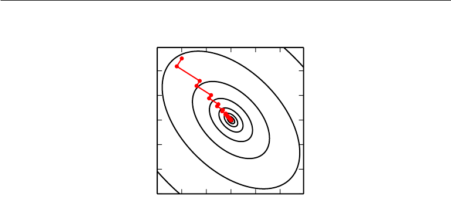

Figure 8.6: The method of steepest descent applied to a quadratic cost surface. The

method of steepest descent involves jumping to the point of lowest cost along the line

deﬁned by the gradient at the initial point on each step. This resolves some of the problems

seen with using a ﬁxed learning rate in ﬁgure 4.6, but even with the optimal step size

the algorithm still makes back-and-forth progress toward the optimum. By deﬁnition, at

the minimum of the objective along a given direction, the gradient at the ﬁnal point is

orthogonal to that direction.

made in the direction of the previous line search. The method of conjugate gradients

seeks to address this problem.

In the method of conjugate gradients, we seek to ﬁnd a search direction that is

conjugate

to the previous line search direction; that is, it will not undo progress

made in that direction. At training iteration

t

, the next search direction

d

t

takes

the form:

d

t

= ∇

θ

J(θ) + β

t

d

t−1

, (8.29)

where

β

t

is a coeﬃcient whose magnitude controls how much of the direction,

d

t−1

,

we should add back to the current search direction.

Two directions,

d

t

and

d

t−1

, are deﬁned as conjugate if

d

t

Hd

t−1

= 0, where

H is the Hessian matrix.

The straightforward way to impose conjugacy would involve calculation of the

eigenvectors of

H

to choose

β

t

, which would not satisfy our goal of developing

a method that is more computationally viable than Newton’s method for large

problems. Can we calculate the conjugate directions without resorting to these

calculations? Fortunately, the answer to that is yes.

Two popular methods for computing the β

t

are

[figure not shown]

1. Fletcher-Reeves:

β

t

=

∇

θ

J(θ

t

)

∇

θ

J(θ

t

)

∇

θ

J(θ

t−1

)

∇

θ

J(θ

t−1

)

(8.30)

2. Polak-Ribière:

β

t

=

(∇

θ

J(θ

t

) − ∇

θ

J(θ

t−1

))

∇

θ

J(θ

t

)

∇

θ

J(θ

t−1

)

∇

θ

J(θ

t−1

)

(8.31)

For a quadratic surface, the conjugate directions ensure that the gradient along

the previous direction does not increase in magnitude. We therefore stay at the

minimum along the previous directions. As a consequence, in a

k

-dimensional

parameter space, the conjugate gradient method requires at most

k

line searches to

achieve the minimum. The conjugate gradient algorithm is given in algorithm 8.9.

Algorithm 8.9 The conjugate gradient method

Require: Initial parameters θ

0

Require: Training set of m examples

Initialize ρ

0

= 0

Initialize g

0

= 0

Initialize t = 1

while stopping criterion not met do

Initialize the gradient g

t

= 0

Compute gradient: g

t

←

1

m

∇

θ

i

L(f(x

(i)

; θ), y

(i)

)

Compute β

t

=

(g

t

−g

t−1

)

g

t

g

t−1

g

t−1

(Polak-Ribière)

(Nonlinear conjugate gradient: optionally reset

β

t

to zero, for example if

t

is

a multiple of some constant k, such as k = 5)

Compute search direction: ρ

t

= −g

t

+ β

t

ρ

t−1

Perform line search to ﬁnd:

∗

= argmin

1

m

m

i=1

L(f(x

(i)

; θ

t

+ ρ

t

), y

(i)

)

(On a truly quadratic cost function, analytically solve for

∗

rather than

explicitly searching for it)

Apply update: θ

t+1

= θ

t

+

∗

ρ

t

t ← t + 1

end while

Nonlinear Conjugate Gradients:

So far we have discussed the method of

conjugate gradients as it is applied to quadratic objective functions. Of course,

our primary interest in this chapter is to explore optimization methods for training

neural networks and other related deep learning models where the corresponding

objective function is far from quadratic. Perhaps surprisingly, the method of

conjugate gradients is still applicable in this setting, though with some modiﬁcation.

Without any assurance that the objective is quadratic, the conjugate directions

are no longer assured to remain at the minimum of the objective for previous

directions. As a result, the

nonlinear conjugate gradients

algorithm includes

occasional resets where the method of conjugate gradients is restarted with line

search along the unaltered gradient.

Practitioners report reasonable results in applications of the nonlinear conjugate

gradients algorithm to training neural networks, though it is often beneﬁcial to

initialize the optimization with a few iterations of stochastic gradient descent before

commencing nonlinear conjugate gradients. Also, while the (nonlinear) conjugate

gradients algorithm has traditionally been cast as a batch method, minibatch

versions have been used successfully for training neural networks (Le et al., 2011).

Adaptations of conjugate gradients speciﬁcally for neural networks have been

proposed earlier, such as the scaled conjugate gradients algorithm (Moller, 1993).

8.6.3 BFGS

The

Broyden–Fletcher–Goldfarb–Shanno (BFGS) algorithm

attempts to

bring some of the advantages of Newton’s method without the computational

burden. In that respect, BFGS is similar to the conjugate gradient method.

However, BFGS takes a more direct approach to the approximation of Newton’s

update. Recall that Newton’s update is given by

θ

∗

= θ

0

− H

−1

∇

θ

J(θ

0

), (8.32)

where

H

is the Hessian of

J

with respect to

θ

evaluated at

θ

0

. The primary

computational diﬃculty in applying Newton’s update is the calculation of the

inverse Hessian

H

−1

. The approach adopted by quasi-Newton methods (of which

the BFGS algorithm is the most prominent) is to approximate the inverse with

a matrix

M

t

that is iteratively reﬁned by low-rank updates to become a better

approximation of H

−1

.

The speciﬁcation and derivation of the BFGS approximation is given in many

textbooks on optimization, including in Luenberger (1984).

Once the inverse Hessian approximation

M

t

is updated, the direction of descent

ρ

t

is determined by

ρ

t

=

M

t

g

t

. A line search is performed in this direction to

determine the size of the step,

∗

, taken in this direction. The ﬁnal update to the

parameters is given by

θ

t+1

= θ

t

+

∗

ρ

t

. (8.33)

Like the method of conjugate gradients, the BFGS algorithm iterates a series

of line searches with the direction incorporating second-order information. Unlike

conjugate gradients, however, the success of the approach is not heavily dependent

on the line search ﬁnding a point very close to the true minimum along the line.

Thus, relative to conjugate gradients, BFGS has the advantage that it can spend

less time reﬁning each line search. On the other hand, the BFGS algorithm must

store the inverse Hessian matrix,

M

, that requires

O

(

n

2

) memory, making BFGS

impractical for most modern deep learning models that typically have millions of

parameters.

Limited Memory BFGS (or L-BFGS)

The memory costs of the BFGS

algorithm can be signiﬁcantly decreased by avoiding storing the complete inverse

Hessian approximation

M

. The L-BFGS algorithm computes the approximation

M

using the same method as the BFGS algorithm but beginning with the assumption

that

M

(t−1)

is the identity matrix, rather than storing the approximation from one

step to the next. If used with exact line searches, the directions deﬁned by L-BFGS

are mutually conjugate. However, unlike the method of conjugate gradients, this

procedure remains well behaved when the minimum of the line search is reached

only approximately. The L-BFGS strategy with no storage described here can be

generalized to include more information about the Hessian by storing some of the

vectors used to update M at each time step, which costs only O(n) per step.

8.7 Optimization Strategies and Meta-Algorithms

Many optimization techniques are not exactly algorithms but rather general tem-

plates that can be specialized to yield algorithms, or subroutines that can be

incorporated into many diﬀerent algorithms.

8.7.1 Batch Normalization

Batch normalization (Ioﬀe and Szegedy, 2015) is one of the most exciting recent

innovations in optimizing deep neural networks, and it is actually not an opti-

mization algorithm at all. Instead, it is a method of adaptive reparametrization,

motivated by the diﬃculty of training very deep models.

Very deep models involve the composition of several functions, or layers. The

gradient tells how to update each parameter, under the assumption that the other

layers do not change. In practice, we update all the layers simultaneously. When we

make the update, unexpected results can happen because many functions composed

together are changed simultaneously, using updates that were computed under

the assumption that the other functions remain constant. As a simple example,

suppose we have a deep neural network that has only one unit per layer and does

not use an activation function at each hidden layer:

ˆy

=

xw

1

w

2

w

3

. . . w

l

. Here,

w

i

provides the weight used by layer

i

. The output of layer

i

is

h

i

=

h

i−1

w

i

. The

output

ˆy

is a linear function of the input

x

but a nonlinear function of the weights

w

i

. Suppose our cost function has put a gradient of 1 on

ˆy

, so we wish to decrease

ˆy

slightly. The back-propagation algorithm can then compute a gradient

g

=

∇

w

ˆy

.

Consider what happens when we make an update

w ← w − g

. The ﬁrst-order

Taylor series approximation of

ˆy

predicts that the value of

ˆy

will decrease by

g

g

.

If we wanted to decrease

ˆy

by 0

.

1, this ﬁrst-order information available in the

gradient suggests we could set the learning rate

to

0.1

g

g

. Yet, the actual update

will include second-order and third-order eﬀects, on up to eﬀects of order

l

. The

new value of ˆy is given by

x(w

1

− g

1

)(w

2

− g

2

) . . . (w

l

− g

l

). (8.34)

An example of one second-order term arising from this update is

2

g

1

g

2

l

i=3

w

i

.

This term might be negligible if

l

i=3

w

i

is small, or might be exponentially large

if the weights on layers 3 through

l

are greater than 1. This makes it very hard

to choose an appropriate learning rate, because the eﬀects of an update to the

parameters for one layer depend so strongly on all the other layers. Second-order

optimization algorithms address this issue by computing an update that takes these

second-order interactions into account, but we can see that in very deep networks,

even higher-order interactions can be signiﬁcant. Even second-order optimization

algorithms are expensive and usually require numerous approximations that prevent

them from truly accounting for all signiﬁcant second-order interactions. Building

an

n

-th order optimization algorithm for

n >

2 thus seems hopeless. What can we

do instead?

Batch normalization provides an elegant way of reparametrizing almost any deep

network. The reparametrization signiﬁcantly reduces the problem of coordinating

updates across many layers. Batch normalization can be applied to any input

or hidden layer in a network. Let

H

be a minibatch of activations of the layer

to normalize, arranged as a design matrix, with the activations for each example

appearing in a row of the matrix. To normalize H, we replace it with

H

=

H − µ

σ

, (8.35)

where

µ

is a vector containing the mean of each unit and

σ

is a vector containing

the standard deviation of each unit. The arithmetic here is based on broadcasting

[figure not shown]

the vector

µ

and the vector

σ

to be applied to every row of the matrix

H

. Within

each row, the arithmetic is element-wise, so

H

i,j

is normalized by subtracting

µ

j

and dividing by

σ

j

. The rest of the network then operates on

H

in exactly the

same way that the original network operated on H.

At training time,

µ =

1

m

i

H

i,:

(8.36)

and

σ =

δ +

1

m

i

(H − µ)

2

i

, (8.37)

where

δ

is a small positive value such as 10

−8

, imposed to avoid encountering

the undeﬁned gradient of

√

z

at

z

= 0. Crucially, we back-propagate through

these operations for computing the mean and the standard deviation, and for

applying them to normalize

H

. This means that the gradient will never propose

an operation that acts simply to increase the standard deviation or mean of

h

i

; the normalization operations remove the eﬀect of such an action and zero

out its component in the gradient. This was a major innovation of the batch

normalization approach. Previous approaches had involved adding penalties to

the cost function to encourage units to have normalized activation statistics or

involved intervening to renormalize unit statistics after each gradient descent step.

The former approach usually resulted in imperfect normalization and the latter

usually resulted in signiﬁcant wasted time, as the learning algorithm repeatedly

proposed changing the mean and variance, and the normalization step repeatedly

undid this change. Batch normalization reparametrizes the model to make some

units always be standardized by deﬁnition, deftly sidestepping both problems.

At test time,

µ

and

σ

may be replaced by running averages that were collected

during training time. This allows the model to be evaluated on a single example,

without needing to use deﬁnitions of

µ

and

σ

that depend on an entire minibatch.

Revisiting the

ˆy

=

xw

1

w

2

. . . w

l

example, we see that we can mostly resolve the

diﬃculties in learning this model by normalizing

h

l−1

. Suppose that

x

is drawn

from a unit Gaussian. Then

h

l−1

will also come from a Gaussian, because the

transformation from

x

to

h

l

is linear. However,

h

l−1

will no longer have zero mean

and unit variance. After applying batch normalization, we obtain the normalized

ˆ

h

l−1

that restores the zero mean and unit variance properties. For almost any

update to the lower layers,

ˆ

h

l−1

will remain a unit Gaussian. The output

ˆy

may

then be learned as a simple linear function

ˆy

=

w

l

ˆ

h

l−1

. Learning in this model is

now very simple because the parameters at the lower layers do not have an eﬀect

in most cases; their output is always renormalized to a unit Gaussian. In some

corner cases, the lower layers can have an eﬀect. Changing one of the lower layer

weights to 0 can make the output become degenerate, and changing the sign of one

of the lower weights can ﬂip the relationship between

ˆ

h

l−1

and

y

. These situations

are very rare. Without normalization, nearly every update would have an extreme

eﬀect on the statistics of

h

l−1

. Batch normalization has thus made this model

signiﬁcantly easier to learn. In this example, the ease of learning of course came at

the cost of making the lower layers useless. In our linear example, the lower layers

no longer have any harmful eﬀect, but they also no longer have any beneﬁcial eﬀect.

This is because we have normalized out the ﬁrst- and second-order statistics, which

is all that a linear network can inﬂuence. In a deep neural network with nonlinear

activation functions, the lower layers can perform nonlinear transformations of

the data, so they remain useful. Batch normalization acts to standardize only the

mean and variance of each unit in order to stabilize learning, but it allows the

relationships between units and the nonlinear statistics of a single unit to change.

Because the ﬁnal layer of the network is able to learn a linear transformation,

we may actually wish to remove all linear relationships between units within a

layer. Indeed, this is the approach taken by Desjardins et al. (2015), who provided

the inspiration for batch normalization. Unfortunately, eliminating all linear

interactions is much more expensive than standardizing the mean and standard

deviation of each individual unit, and so far batch normalization remains the most

practical approach.

Normalizing the mean and standard deviation of a unit can reduce the expressive

power of the neural network containing that unit. To maintain the expressive

power of the network, it is common to replace the batch of hidden unit activations

H

with

γH

+

β

rather than simply the normalized

H

. The variables

γ

and

β

are learned parameters that allow the new variable to have any mean and standard

deviation. At ﬁrst glance, this may seem useless—why did we set the mean to

0

,

and then introduce a parameter that allows it to be set back to any arbitrary value

β? The answer is that the new parametrization can represent the same family of

functions of the input as the old parametrization, but the new parametrization

has diﬀerent learning dynamics. In the old parametrization, the mean of

H

was

determined by a complicated interaction between the parameters in the layers

below

H

. In the new parametrization, the mean of

γH

+

β

is determined solely

by β. The new parametrization is much easier to learn with gradient descent.

Most neural network layers take the form of

φ

(

XW

+

b

), where

φ

is some

ﬁxed nonlinear activation function such as the rectiﬁed linear transformation. It

is natural to wonder whether we should apply batch normalization to the input

X

, or to the transformed value

XW

+

b

. Ioﬀe and Szegedy (2015) recommend

the latter. More speciﬁcally,

XW

+

b

should be replaced by a normalized version

of

XW

. The bias term should be omitted because it becomes redundant with

the

β

parameter applied by the batch normalization reparametrization. The input

to a layer is usually the output of a nonlinear activation function such as the

rectiﬁed linear function in a previous layer. The statistics of the input are thus

more non-Gaussian and less amenable to standardization by linear operations.

In convolutional networks, described in chapter 9, it is important to apply the

same normalizing

µ

and

σ

at every spatial location within a feature map, so that

the statistics of the feature map remain the same regardless of spatial location.

8.7.2 Coordinate Descent

In some cases, it may be possible to solve an optimization problem quickly by

breaking it into separate pieces. If we minimize

f

(

x

) with respect to a single

variable

x

i

, then minimize it with respect to another variable

x

j

, and so on,

repeatedly cycling through all variables, we are guaranteed to arrive at a (local)

minimum. This practice is known as

coordinate descent

, because we optimize

one coordinate at a time. More generally,

block coordinate descent

refers to

minimizing with respect to a subset of the variables simultaneously. The term

“coordinate descent” is often used to refer to block coordinate descent as well as

the strictly individual coordinate descent.

Coordinate descent makes the most sense when the diﬀerent variables in the

optimization problem can be clearly separated into groups that play relatively

isolated roles, or when optimization with respect to one group of variables is

signiﬁcantly more eﬃcient than optimization with respect to all of the variables.

For example, consider the cost function

J(H, W ) =

i,j

|H

i,j

| +

i,j

X − W

H

2

i,j

. (8.38)

This function describes a learning problem called sparse coding, where the goal is

to ﬁnd a weight matrix

W

that can linearly decode a matrix of activation values

H

to reconstruct the training set

X

. Most applications of sparse coding also

involve weight decay or a constraint on the norms of the columns of

W

, to prevent

the pathological solution with extremely small H and large W .

The function

J

is not convex. However, we can divide the inputs to the

training algorithm into two sets: the dictionary parameters

W

and the code

representations

H

. Minimizing the objective function with respect to either one of

these sets of variables is a convex problem. Block coordinate descent thus gives

[figure not shown]

us an optimization strategy that allows us to use eﬃcient convex optimization

algorithms, by alternating between optimizing

W

with

H

ﬁxed, then optimizing

H with W ﬁxed.

Coordinate descent is not a very good strategy when the value of one variable

strongly inﬂuences the optimal value of another variable, as in the function

f

(

x

) =

(

x

1

−x

2

)

2

+

α

x

2

1

+ x

2

2

where

α

is a positive constant. The ﬁrst term encourages

the two variables to have similar value, while the second term encourages them

to be near zero. The solution is to set both to zero. Newton’s method can solve

the problem in a single step because it is a positive deﬁnite quadratic problem.

For small

α

, however, coordinate descent will make very slow progress because the

ﬁrst term does not allow a single variable to be changed to a value that diﬀers

signiﬁcantly from the current value of the other variable.

8.7.3 Polyak Averaging

Polyak averaging (Polyak and Juditsky, 1992) consists of averaging several points

in the trajectory through parameter space visited by an optimization algorithm. If

t

iterations of gradient descent visit points

θ

(1)

, . . . , θ

(t)

, then the output of the

Polyak averaging algorithm is

ˆ

θ

(t)

=

1

t

i

θ

(i)

. On some problem classes, such as

gradient descent applied to convex problems, this approach has strong convergence

guarantees. When applied to neural networks, its justiﬁcation is more heuristic,

but it performs well in practice. The basic idea is that the optimization algorithm

may leap back and forth across a valley several times without ever visiting a point

near the bottom of the valley. The average of all the locations on either side should

be close to the bottom of the valley though.

In nonconvex problems, the path taken by the optimization trajectory can be

very complicated and visit many diﬀerent regions. Including points in parameter

space from the distant past that may be separated from the current point by large

barriers in the cost function does not seem like a useful behavior. As a result,

when applying Polyak averaging to nonconvex problems, it is typical to use an

exponentially decaying running average:

ˆ

θ

(t)

= α

ˆ

θ

(t−1)

+ (1 − α)θ

(t)

. (8.39)

The running average approach is used in numerous applications. See Szegedy

et al. (2015) for a recent example.

8.7.4 Supervised Pretraining

Sometimes, directly training a model to solve a speciﬁc task can be too ambitious

if the model is complex and hard to optimize or if the task is very diﬃcult. It is

sometimes more eﬀective to train a simpler model to solve the task, then make

the model more complex. It can also be more eﬀective to train the model to solve

a simpler task, then move on to confront the ﬁnal task. These strategies that

involve training simple models on simple tasks before confronting the challenge of

training the desired model to perform the desired task are collectively known as

pretraining.

Greedy algorithms

break a problem into many components, then solve for

the optimal version of each component in isolation. Unfortunately, combining the

individually optimal components is not guaranteed to yield an optimal complete

solution. Nonetheless, greedy algorithms can be computationally much cheaper

than algorithms that solve for the best joint solution, and the quality of a greedy

solution is often acceptable if not optimal. Greedy algorithms may also be followed

by a

ﬁne-tuning

stage in which a joint optimization algorithm searches for an

optimal solution to the full problem. Initializing the joint optimization algorithm

with a greedy solution can greatly speed it up and improve the quality of the

solution it ﬁnds.

Pretraining, and especially greedy pretraining, algorithms are ubiquitous in

deep learning. In this section, we describe speciﬁcally those pretraining algorithms

that break supervised learning problems into other simpler supervised learning

problems. This approach is known as greedy supervised pretraining.

In the original (Bengio et al., 2007) version of greedy supervised pretraining,

each stage consists of a supervised learning training task involving only a subset of

the layers in the ﬁnal neural network. An example of greedy supervised pretraining

is illustrated in ﬁgure 8.7, in which each added hidden layer is pretrained as part

of a shallow supervised MLP, taking as input the output of the previously trained

hidden layer. Instead of pretraining one layer at a time, Simonyan and Zisserman

(2015) pretrain a deep convolutional network (eleven weight layers) and then use

the ﬁrst four and last three layers from this network to initialize even deeper

networks (with up to nineteen layers of weights). The middle layers of the new,

very deep network are initialized randomly. The new network is then jointly trained.

Another option, explored by Yu et al. (2010), is to use the outputs of the previously

trained MLPs, as well as the raw input, as inputs for each added stage.

Why would greedy supervised pretraining help? The hypothesis initially

discussed by Bengio et al. (2007) is that it helps to provide better guidance to the

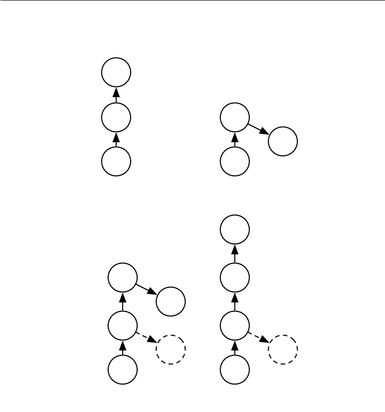

yy

h

(1)

h

(1)

xx

(a)

U

(1)

U

(1)

W

(1)

W

(1)

yy

h

(1)

h

(1)

xx

(b)

U

(1)

U

(1)

W

(1)

W

(1)

yy

h

(1)

h

(1)

xx

(c)

U

(1)

U

(1)

W

(1)

W

(1)

h

(2)

h

(2)

yy

U

(2)

U

(2)

W

(2)

W

(2)

yy

h

(1)

h

(1)

xx

(d)

U

(1)

U

(1)

W

(1)

W

(1)

h

(2)

h

(2)

y

U

(2)

U

(2)

W

(2)

W

(2)

Figure 8.7: Illustration of one form of greedy supervised pretraining (Bengio et al., 2007).

(a)We start by training a suﬃciently shallow architecture. (b)Another drawing of the

same architecture. (c)We keep only the input-to-hidden layer of the original network and

discard the hidden-to-output layer. We send the output of the ﬁrst hidden layer as input

to another supervised single hidden layer MLP that is trained with the same objective

as the ﬁrst network was, thus adding a second hidden layer. This can be repeated for as

many layers as desired. (d)Another drawing of the result, viewed as a feedforward network.

To further improve the optimization, we can jointly ﬁne-tune all the layers, either only at

the end or at each stage of this process.

intermediate levels of a deep hierarchy. In general, pretraining may help both in

terms of optimization and generalization.

An approach related to supervised pretraining extends the idea to the context

of transfer learning: Yosinski et al. (2014) pretrain a deep convolutional net with

eight layers of weights on a set of tasks (a subset of the 1,000 ImageNet object

categories) and then initialize a same-size network with the ﬁrst

k

layers of the

ﬁrst net. All the layers of the second network (with the upper layers initialized

randomly) are then jointly trained to perform a diﬀerent set of tasks (another

subset of the 1,000 ImageNet object categories), with fewer training examples

than for the ﬁrst set of tasks. Other approaches to transfer learning with neural

networks are discussed in section 15.2.

Another related line of work is the

FitNets

(Romero et al., 2015) approach.

This approach begins by training a network that has low enough depth and great

enough width (number of units per layer) to be easy to train. This network then

becomes a

teacher

for a second network, designated the

student

. The student

network is much deeper and thinner (eleven to nineteen layers) and would be

diﬃcult to train with SGD under normal circumstances. The training of the

student network is made easier by training the student network not only to predict

the output for the original task, but also to predict the value of the middle layer of

the teacher network. This extra task provides a set of hints about how the hidden

layers should be used and can simplify the optimization problem. Additional

parameters are introduced to regress the middle layer of the ﬁve layer teacher

network from the middle layer of the deeper student network. Instead of predicting

the ﬁnal classiﬁcation target, however, the objective is to predict the middle hidden

layer of the teacher network. The lower layers of the student networks thus have

two objectives: to help the outputs of the student network accomplish their task,

as well as to predict the intermediate layer of the teacher network. Although a thin

and deep network appears to be more diﬃcult to train than a wide and shallow

network, the thin and deep network may generalize better and certainly has lower

computational cost if it is thin enough to have far fewer parameters. Without

the hints on the hidden layer, the student network performs very poorly in the

experiments, on both the training and the test set. Hints on middle layers may

thus be one of the tools to help train neural networks that otherwise seem diﬃcult

to train, but other optimization techniques or changes in the architecture may also

solve the problem.

8.7.5 Designing Models to Aid Optimization

To improve optimization, the best strategy is not always to improve the optimization

algorithm. Instead, many improvements in the optimization of deep models have

come from designing the models to be easier to optimize.

In principle, we could use activation functions that increase and decrease

in jagged nonmonotonic patterns, but this would make optimization extremely

diﬃcult. In practice, it is more important to choose a model family that is easy to

optimize than to use a powerful optimization algorithm. Most of the advances in

neural network learning over the past thirty years have been obtained by changing

the model family rather than changing the optimization procedure. Stochastic

gradient descent with momentum, which was used to train neural networks in the

1980s, remains in use in modern state-of-the-art neural network applications.

Speciﬁcally, modern neural networks reﬂect a design choice to use linear trans-

formations between layers and activation functions that are diﬀerentiable almost

everywhere, with signiﬁcant slope in large portions of their domain. In particular,

model innovations like the LSTM, rectiﬁed linear units and maxout units have

all moved toward using more linear functions than previous models like deep

networks based on sigmoidal units. These models have nice properties that make

optimization easier. The gradient ﬂows through many layers provided that the

Jacobian of the linear transformation has reasonable singular values. Moreover,

linear functions consistently increase in a single direction, so even if the model’s

output is very far from correct, it is clear simply from computing the gradient

which direction its output should move to reduce the loss function. In other words,

modern neural nets have been designed so that their local gradient information

corresponds reasonably well to moving toward a distant solution.

Other model design strategies can help to make optimization easier. For

example, linear paths or skip connections between layers reduce the length of

the shortest path from the lower layer’s parameters to the output, and thus

mitigate the vanishing gradient problem (Srivastava et al., 2015). A related idea

to skip connections is adding extra copies of the output that are attached to the

intermediate hidden layers of the network, as in GoogLeNet (Szegedy et al., 2014a)

and deeply supervised nets (Lee et al., 2014). These “auxiliary heads” are trained

to perform the same task as the primary output at the top of the network to

ensure that the lower layers receive a large gradient. When training is complete,

the auxiliary heads may be discarded. This is an alternative to the pretraining

strategies, which were introduced in the previous section. In this way, one can

train jointly all the layers in a single phase but change the architecture, so that

intermediate layers (especially the lower ones) can get some hints about what they

should do, via a shorter path. These hints provide an error signal to lower layers.

8.7.6 Continuation Methods and Curriculum Learning

As argued in section 8.2.7, many of the challenges in optimization arise from the

global structure of the cost function and cannot be resolved merely by making better

estimates of local update directions. The predominant strategy for overcoming

this problem is to attempt to initialize the parameters in a region connected to the

solution by a short path through parameter space that local descent can discover.

Continuation methods

are a family of strategies that can make optimization

easier by choosing initial points to ensure that local optimization spends most of

its time in well-behaved regions of space. The idea behind continuation methods is

to construct a series of objective functions over the same parameters. To minimize

a cost function

J

(

θ

), we construct new cost functions

{J

(0)

, . . . , J

(n)

}

. These cost

functions are designed to be increasingly diﬃcult, with

J

(0)

being fairly easy to

minimize, and

J

(n)

, the most diﬃcult, being

J

(

θ

), the true cost function motivating

the entire process. When we say that

J

(i)

is easier than

J

(i+1)

, we mean that it

is well behaved over more of

θ

space. A random initialization is more likely to

land in the region where local descent can minimize the cost function successfully

because this region is larger. The series of cost functions are designed so that a

solution to one is a good initial point of the next. We thus begin by solving an

easy problem, then reﬁne the solution to solve incrementally harder problems until

we arrive at a solution to the true underlying problem.

Traditional continuation methods (predating the use of continuation methods

for neural network training) are usually based on smoothing the objective function.

See Wu (1997) for an example of such a method and a review of some related

methods. Continuation methods are also closely related to simulated annealing,

which adds noise to the parameters (Kirkpatrick et al., 1983). Continuation

methods have been extremely successful in recent years. See Mobahi and Fisher

(2015) for an overview of recent literature, especially for AI applications.

Continuation methods traditionally were mostly designed with the goal of

overcoming the challenge of local minima. Speciﬁcally, they were designed to

reach a global minimum despite the presence of many local minima. To do so,

these continuation methods would construct easier cost functions by “blurring” the

original cost function. This blurring operation can be done by approximating

J

(i)

(θ) = E

θ

∼N(θ

;θ,σ

(i)2

)

J(θ

) (8.40)

via sampling. The intuition for this approach is that some nonconvex functions

become approximately convex when blurred. In many cases, this blurring preserves

enough information about the location of a global minimum that we can ﬁnd the

global minimum by solving progressively less-blurred versions of the problem. This

approach can break down in three diﬀerent ways. First, it might successfully deﬁne

a series of cost functions where the ﬁrst is convex and the optimum tracks from

one function to the next, arriving at the global minimum, but it might require so

many incremental cost functions that the cost of the entire procedure remains high.

NP-hard optimization problems remain NP-hard, even when continuation methods

are applicable. The other two ways continuation methods fail both correspond to

the method not being applicable. First, the function might not become convex, no

matter how much it is blurred. Consider, for example, the function

J

(

θ

) =

−θ

θ

.

Second, the function may become convex as a result of blurring, but the minimum

of this blurred function may track to a local rather than a global minimum of the

original cost function.

Though continuation methods were mostly originally designed to deal with the

problem of local minima, local minima are no longer believed to be the primary

problem for neural network optimization. Fortunately, continuation methods can

still help. The easier objective functions introduced by the continuation method can

eliminate ﬂat regions, decrease variance in gradient estimates, improve conditioning

of the Hessian matrix, or do anything else that will either make local updates

easier to compute or improve the correspondence between local update directions

and progress toward a global solution.

Bengio et al. (2009) observed that an approach called

curriculum learning

,

or

shaping

, can be interpreted as a continuation method. Curriculum learning is

based on the idea of planning a learning process to begin by learning simple concepts

and progress to learning more complex concepts that depend on these simpler

concepts. This basic strategy was previously known to accelerate progress in animal

training (Skinner, 1958; Peterson, 2004; Krueger and Dayan, 2009) and in machine

learning (Solomonoﬀ, 1989; Elman, 1993; Sanger, 1994). Bengio et al. (2009)

justiﬁed this strategy as a continuation method, where earlier

J

(i)

are made easier by

increasing the inﬂuence of simpler examples (either by assigning their contributions

to the cost function larger coeﬃcients, or by sampling them more frequently), and

experimentally demonstrated that better results could be obtained by following a

curriculum on a large-scale neural language modeling task. Curriculum learning

has been successful on a wide range of natural language (Spitkovsky et al., 2010;

Collobert et al., 2011a; Mikolov et al., 2011b; Tu and Honavar, 2011) and computer

vision (Kumar et al., 2010; Lee and Grauman, 2011; Supancic and Ramanan, 2013)

tasks. Curriculum learning was also veriﬁed as being consistent with the way in

which humans teach (Khan et al., 2011): teachers start by showing easier and

more prototypical examples and then help the learner reﬁne the decision surface

with the less obvious cases. Curriculum-based strategies are more eﬀective for

teaching humans than strategies based on uniform sampling of examples and can

also increase the eﬀectiveness of other teaching strategies (Basu and Christensen,

2013).

Another important contribution to research on curriculum learning arose in the

context of training recurrent neural networks to capture long-term dependencies:

Zaremba and Sutskever (2014) found that much better results were obtained with a

stochastic curriculum, in which a random mix of easy and diﬃcult examples is always

presented to the learner, but where the average proportion of the more diﬃcult

examples (here, those with longer-term dependencies) is gradually increased. With

a deterministic curriculum, no improvement over the baseline (ordinary training

from the full training set) was observed.

We have now described the basic family of neural network models and how to

regularize and optimize them. In the chapters ahead, we turn to specializations of

the neural network family that allow neural networks to scale to very large sizes and

process input data that has special structure. The optimization methods discussed

in this chapter are often directly applicable to these specialized architectures with

little or no modiﬁcation.